# TFM — SERVICIO DE INSPECCIÓN DEL WASHINGTON COUNTY

Y hacemos lo mismo con las numéricas. El resultado, como no podía ser de otra manera, muestra la relación de la puntuación de la inspección con las inspecciones con resultado insatisfactorio

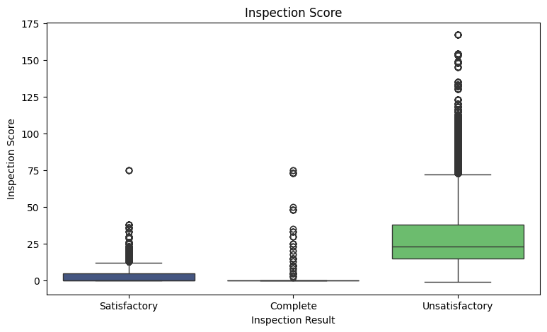

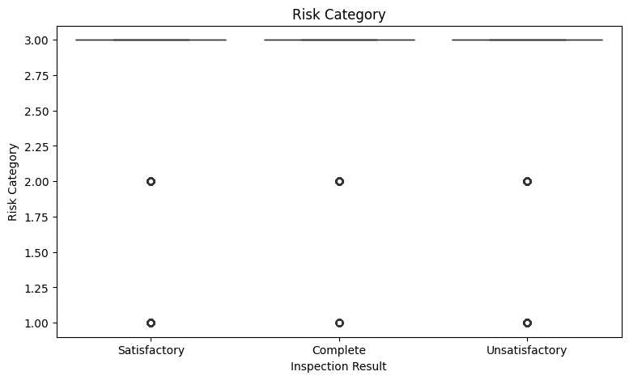

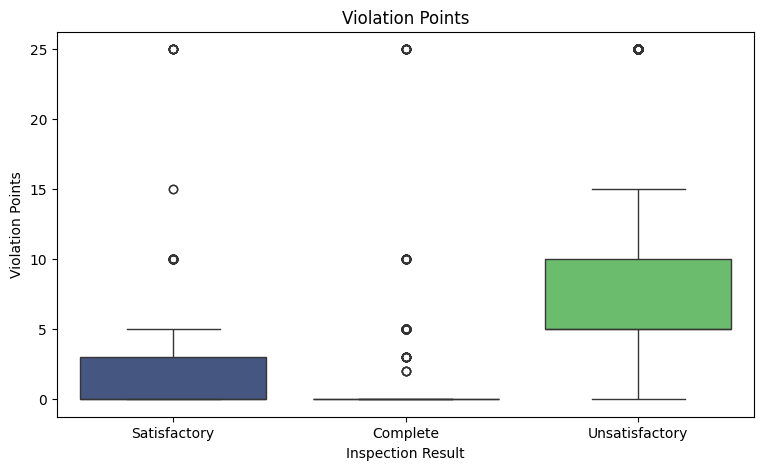

```python
for columna in numericas:

    plt.figure(figsize=(9,5))

    sns.boxplot(

        data=raw_original,

        x="Inspection Result",

        y=columna,

        palette="viridis"

    )

    plt.title(columna)

    plt.show()
```

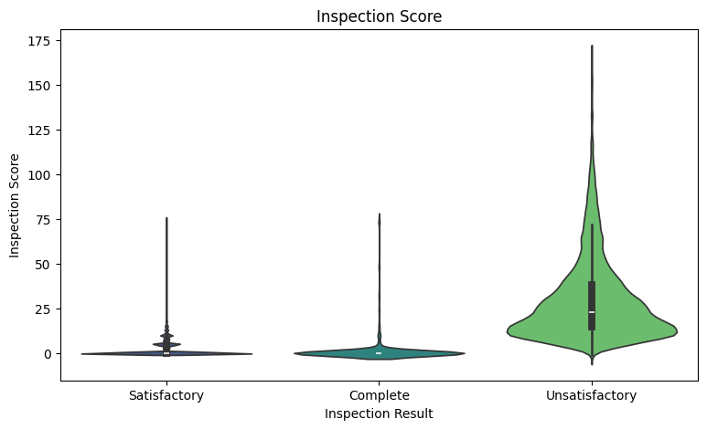

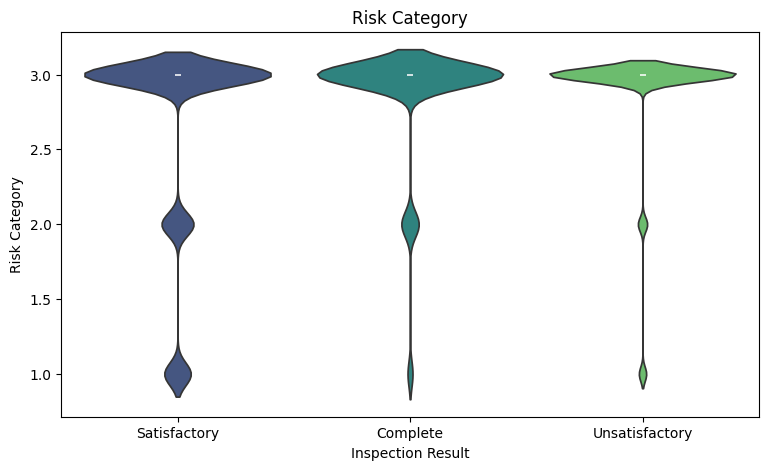

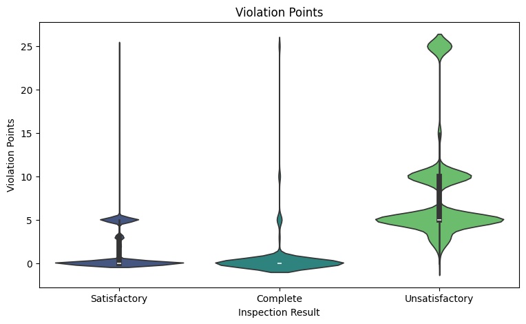

```python
for columna in numericas:

    plt.figure(figsize=(9,5))

    sns.violinplot(

        data=raw_original,

        x="Inspection Result",

        y=columna,

        palette="viridis"

    )

    plt.title(columna)

    plt.show()
```

Por último, y por si más adelante, una vez hecha la limpieza, se pudieran agrupar, estudiamos qué variables categóricas tienen poca frecuencia, pero las características mismas del estudio hacen complejo que se agrupen, ya que pej. la existencia de ciudades o códigos postales en las que el número de infracciones registradas es inferior a 10 puede estar vinculado a factores como la población que allí reside. Por otro lado, tampoco que existan establecimientos que tienen menos de 10 inspecciones nos permitiría agruparlos pues ese menor número de inspecciones puede estar asociado a factores como, pej. su reciente creación lo que nos llevaría a tratar de forma unificada realidades que no responden necesariamente a un mismo patrón.

```python
for columna in categoricas:

    frecuencia = raw_original[columna].value_counts()

    raras = (frecuencia < 10).sum()

    print(f"{columna:25} -> {raras} categorías aparecen menos de 10 veces")
```

```
Name                      -> 5882 categorías aparecen menos de 10 veces
Program Identifier        -> 1764 categorías aparecen menos de 10 veces
Inspection Date           -> 224 categorías aparecen menos de 10 veces
Classification            -> 2 categorías aparecen menos de 10 veces
Address                   -> 5417 categorías aparecen menos de 10 veces
City                      -> 33 categorías aparecen menos de 10 veces
Zip Code                  -> 42 categorías aparecen menos de 10 veces
Inspection Type           -> 0 categorías aparecen menos de 10 veces
Inspection Result         -> 0 categorías aparecen menos de 10 veces
Inspection Closed Business -> 0 categorías aparecen menos de 10 veces
Seating Range             -> 0 categorías aparecen menos de 10 veces
Violation Type            -> 0 categorías aparecen menos de 10 veces
Violation Description     -> 1 categorías aparecen menos de 10 veces
Grade                     -> 0 categorías aparecen menos de 10 veces
Parcel Number             -> 2851 categorías aparecen menos de 10 veces
Business_ID               -> 8101 categorías aparecen menos de 10 veces
Inspection_Serial_Num     -> 71903 categorías aparecen menos de 10 veces
```

La conclusión de este análisis previo es que nos encontramos ante un dataset con un relevante número de registros en el que el alto número de variables categóricas y su alta cardinalidad van a ser determinantes de cara a la elección del modelo.

# Funciones básicas y limpieza inicial

Como adelantábamos más arriba, en los trabajos previos hemos podido comprobar que el volcado de la información no siempre se lleva a cabo de forma estandarizada, por lo que el primer paso será eliminar espacios, unificar las denominaciones de los valores nulos, normalizar literales, abreviaturas, etc. Salvo en aquellas variables con un gran número de nulos, que son objeto de tratamiento singularizado, optamos por imputar los nulos por la moda, dado el ínfimo porcentaje que suponen.

```python
def first_non_null(s):
    """Devuelve el primer valor no nulo de una serie."""
    s = s.dropna()
    return s.iloc[0] if len(s) else np.nan


def unique_join(s):
    """Une valores únicos no nulos"""
    vals = (
        s.dropna().astype(str).str.strip()
        .replace({"": np.nan})
        .dropna().unique()
    )
    return " | ".join(sorted(vals))


def normalize_columns(df):
    """normalización de literales."""
    df = df.copy()
    df.columns = (
        df.columns.str.strip()
        .str.lower()
        .str.replace(" ", "_", regex=False)
        .str.replace("-", "_", regex=False)
    )
    return df


def normalize_text_columns(df):
    """Normalizo texto para evitar categorías duplicadas por mayúsculas/espacios."""
    df = df.copy()
    text_cols = [
        "name", "address", "city", "classification", "inspection_type",
        "inspection_result", "inspection_closed_business", "seating_range",
        "violation_type", "violation_description", "grade",
        "business_id", "inspection_serial_num"
    ]
    for col in text_cols:
        if col in df.columns:
            df[col] = (
                df[col].astype(str)
                .str.strip()
                .str.lower()
                .str.replace(r"\s+", " ", regex=True)
            )
    return df


def normalize_address(address):
    """Normalizo dirección para poder imputar ciudad/dirección por coincidencias y facilitar información al inspector."""
    if pd.isna(address):
        return pd.NA

    abbreviations = {
        "ST": "STREET", "STE": "SUITE", "AVE": "AVENUE", "AV": "AVENUE",
        "RD": "ROAD", "RDG": "RIDGE", "BLVD": "BOULEVARD", "DR": "DRIVE",
        "LN": "LANE", "CT": "COURT", "CIR": "CIRCLE", "PL": "PLACE",
        "PKWY": "PARKWAY", "HWY": "HIGHWAY", "TER": "TERRACE",
        "TRL": "TRAIL", "SQ": "SQUARE", "EXPY": "EXPRESSWAY",
        "TPKE": "TURNPIKE", "N": "NORTH", "S": "SOUTH", "E": "EAST",
        "W": "WEST", "NE": "NORTHEAST", "NW": "NORTHWEST",
        "SE": "SOUTHEAST", "SW": "SOUTHWEST"
    }

    address = str(address).upper().strip().replace(".", "")
    address = re.sub(r"[^A-Z0-9\s]", " ", address)
    address = re.sub(r"\s+", " ", address).strip()
    return " ".join(abbreviations.get(w, w) for w in address.split())


def add_mode_imputation(df, target, keys):
    """
    Imputo una variable categórica usando la moda por las claves indicadas.
        """
    df = df.copy()
    ref = (
        df.dropna(subset=[target] + keys)
        .groupby(keys)[target]
        .agg(lambda x: x.mode().iloc[0] if not x.mode().empty else pd.NA)
    )
    mask = df[target].isna()
    if mask.any():
        idx = df.loc[mask, keys].apply(tuple, axis=1)
        mapping = ref.to_dict()
        df.loc[mask, target] = idx.map(mapping).values
    return df


def safe_str_series(s, default="UNKNOWN"):
      return (
        s.astype("string").str.strip()
        .replace({"": pd.NA, "nan": pd.NA, "none": pd.NA})
        .fillna(default)
    )

# en este momento también separo los datos de la fecha de las inspecciones, porque los voy a necesitar para mis filtros.
def add_common_features(df):
    """Añade variables de calendario y marco las infracciones para apreciar reincidencia."""
    df = df.copy()
    df["inspection_month"] = df["inspection_date"].dt.month
    df["inspection_quarter"] = df["inspection_date"].dt.quarter
    df["inspection_year"] = df["inspection_date"].dt.year

#  Como hemos adelantado, depuro que si la descripción/tipo vacío significa "sin infracción documentada", ya que si no tengo infracción la inspeccción no es un nulo, sino sencillamente que no se ha producido.
    desc = df["violation_descriptions"].fillna("").astype(str)
    types = df["violation_types"].fillna("").astype(str)

    df["has_red_violation"] = types.str.contains("red", case=False, na=False).astype(int)
    df["has_blue_violation"] = types.str.contains("blue", case=False, na=False).astype(int)
    df["has_any_violation"] = (df["number_violations"] > 0).astype(int)

    # determino el resultado actual: nos será útil para predecir la siguiente inspección porque en el momento de planificar la siguiente ya conocemos el resultado actual.
    df["current_unsatisfactory"] = (
        df["inspection_result"].eq("unsatisfactory").astype(int)
    )
    return df
```

# Datos esenciales

### Construcción de inspecciones e histórico

Sabemos, porque nos lo facilita la fuente de los datos que un mismo (inspection_serial_num) puede tener varias filas porque contiene varias infracciones. Por eso consolido los datos para evita contar una misma inspección varias veces y el paso siguiente es construir el dataset sobre la referencia de la inspección.

Al tiempo, como lo que queremos conocer es la historia de cada establecimiento, y ver cuál ha sido su evolución, construyo un histórico, que me permite hacer un seguimiento de las tres últimas inspecciones, para detectar tanto reincidencia en un tipo de infracción concreto, como una tendencia.

No descarto el resto de los valores en ningún momento, ya que pueden ser útiles para su tratamiento singularizado, pero conservo la información en distintos csv.

```python
def build_inspections(raw):
    """
    Consolido las filas de infracciones a nivel de acta.

    """
    sort_cols = ["business_id", "inspection_date", "inspection_serial_num"]
    tmp = raw.sort_values(sort_cols, kind="mergesort").copy()

    # Y genero un dataset que agrega para las variables que son las claves del acta.
    inspections = (
        tmp.groupby("inspection_serial_num", sort=False)
        .agg(
            business_id=("business_id", "first"),
            name=("name", "first"),
            inspection_date=("inspection_date", "first"),
            classification=("classification", "first"),
            address=("address", "first"),
            city=("city", "first"),
            zip_code=("zip_code", "first"),
            parcel_number=("parcel_number", "first"),
            inspection_type=("inspection_type", "first"),
            inspection_closed_business=("inspection_closed_business", "first"),
            seating_range=("seating_range", "first"),
            risk_category=("risk_category", "first"),
            inspection_score=("inspection_score", "first"),
            grade=("grade_treated", "first"),
            violation_points=("violation_points", "sum"),
            number_violations=("has_violation_row", "sum"),
            inspection_result=("inspection_result_clean", "first"),
        )
        .reset_index()
    )

    # Las descripciones y tipos de infracción se agregan aparte porque van a ser esenciales.
    # La acumulación de tipologias concretas de variables puede ser un indicio de la necesidad de modificar la normativa.

    v = tmp.loc[
        tmp["has_violation_row"],
        ["inspection_serial_num", "violation_description", "violation_type"]
    ].drop_duplicates()

    if not v.empty:
        v_desc = (
            v.dropna(subset=["violation_description"])
            .groupby("inspection_serial_num", sort=False)["violation_description"]
            .agg(" | ".join)
            .rename("violation_descriptions")
        )
        v_type = (
            v.dropna(subset=["violation_type"])
            .groupby("inspection_serial_num", sort=False)["violation_type"]
            .agg(" | ".join)
            .rename("violation_types")
        )
        inspections = inspections.merge(v_desc, on="inspection_serial_num", how="left")
        inspections = inspections.merge(v_type, on="inspection_serial_num", how="left")
    else:
        inspections["violation_descriptions"] = np.nan
        inspections["violation_types"] = np.nan

    inspections["violation_set"] = (
        inspections["violation_descriptions"].fillna("")
        .apply(lambda x: {v.strip() for v in x.split(" | ") if v.strip()})
    )

    inspections = inspections.sort_values(
        ["business_id", "inspection_date", "inspection_serial_num"]
    ).reset_index(drop=True)

    return inspections


def add_history_features(inspections):


    df = inspections.copy()
    g = df.groupby("business_id", group_keys=False)

    df["next_inspection_date"] = g["inspection_date"].shift(-1)
    df["next_inspection_result"] = g["inspection_result"].shift(-1)
    df["days_to_next_inspection"] = (
        df["next_inspection_date"] - df["inspection_date"]
    ).dt.days

    df["next_violation_set"] = g["violation_set"].shift(-1)

    df["reincidence"] = (
        df["next_inspection_result"].eq("unsatisfactory")
        .fillna(False).astype(int)
    )

    def overlap(row):
        current = row["violation_set"]
        nxt = row["next_violation_set"]
        if not isinstance(current, set) or not current:
            return 0
        if not isinstance(nxt, set) or not nxt:
            return 0
        return int(bool(current.intersection(nxt)))

    df["specific_recurrence"] = df.apply(overlap, axis=1)

    # Historial disponible ANTES de la inspección actual. Es relevante porque como hemos adelantado, no todos los establecimientos tienen que haber tenido inspecciones previas

    df["previous_inspections"] = g.cumcount()

    df["previous_unsatisfactory"] = (
        g["inspection_result"]
        .transform(lambda x: x.eq("unsatisfactory").shift(1).fillna(False).cumsum())
    )

    df["previous_unsatisfactory_rate"] = (
        df["previous_unsatisfactory"]
        / df["previous_inspections"].replace(0, np.nan)
    )

    df["previous_violations"] = (
        g["number_violations"]
        .transform(lambda x: x.shift(1).fillna(0).cumsum())
    )

    df["previous_violation_points"] = (
        g["violation_points"]
        .transform(lambda x: x.shift(1).fillna(0).cumsum())
    )

    df["previous_avg_violation_points"] = (
        g["violation_points"].transform(
            lambda x: x.shift(1).expanding().mean()
        )
    )

    df["previous_max_violation_points"] = (
        g["violation_points"].transform(
            lambda x: x.shift(1).expanding().max()
        )
    )

    df["days_since_previous"] = (
        df.groupby("business_id")["inspection_date"].diff().dt.days
    )

    df["previous_result"] = g["inspection_result"].shift(1)
    df["previous_inspection_points"] = g["violation_points"].shift(1)

    # Pero además del histórico, el inspector puede necesitar evaluar qué ha sucedido antes, esto es contar con la información anterior a la inspección actual.
    df["unsat_last_3"] = (
        g["current_unsatisfactory"]
        .transform(lambda x: x.shift(1).rolling(3, min_periods=1).sum())
        .fillna(0)
    )

    df["violations_last_3"] = (
        g["number_violations"]
        .transform(lambda x: x.shift(1).rolling(3, min_periods=1).sum())
        .fillna(0)
    )

    df["points_last_3"] = (
        g["violation_points"]
        .transform(lambda x: x.shift(1).rolling(3, min_periods=1).sum())
        .fillna(0)
    )

    df["points_trend_last_5"] = (
        g["violation_points"]
        .transform(
            lambda x: x.shift(1).rolling(5, min_periods=2)
            .apply(lambda z: np.polyfit(np.arange(len(z)), z, 1)[0], raw=True)
        )
    )

    # La primera inspección de cada negocio va a ser esencial para valorar el riesgo del resultado en una primera inspección.
    df["is_first_observed_inspection"] = (df["previous_inspections"] == 0).astype(int)

    return df
```

### Limpieza y consolidación

El trabajo que se sintetiza en esta celda proviene de las decisiones adoptadas tras revisar una a una la problemática de cada variable y que se acompañan en el anexo. Tambien preparo los datos para su tratamiento posterior. Las decisiones más relevantes son:

- Program Identifier tenía un porcentaje de nulos de un 80%. Tras tratar de depurar se descarta porque se llega a la conclusión que en ese apartado los inspectores anotan distintas casuísticas imposibles de sistematizar.
- Parcel Number lo conservo en string para no perder los ceros conserva como string para no perder identificadores. En en análisis previo se ha detectado su utilidad para identificar ubicaciones de establecimientos que resultan especialmente interesantes por su elevada reincidencia. Los valores nulos se conservan como nan, pero antes agrupo todos aquellos casos que he detectado que recogían denominaciones que eran equivalentes a un nulo.
- City: para cumplimentar los nulos la primera opción será encontrar si el mismo establecimiento tiene otra inspección previa en la que sí esté cumplimentada la ciudad, y si no, se recoge la moda del código postal en el que ese business id está ubicado. Si no hay ciudad ni código postal, se guarda como desconocido.
- Address: mismo criterio que city.
- Risk category: mismo criterio.
- Seating range: trato como "not rated" esta variable a las categorías que he detectado que no tienen asientos en sus establecimientos. para los que, dentro de general food services siguen siendo nulos. Para los que sí tienen que tenerla, aplicamos el criterio de buscar otra inspección en ese establecimiento, y si no, la moda.
- Grade: Al igual que seating range, el problema detectado es que existían tipologías de establecimientos que no recibían valoración en este apartado. Por ello, se incorporar para ellas una nueva categoría de "not_rated" pues no se trata de auténticos nulos.
- Violations descriptions/type: Esta es la solución conceptual al problema de "inspections" más relevante, ya que un NULL en violation_description/type no significa "dato desconocido". Cuando la inspección tiene 0 puntos y no hay infracción: significa que no se ha producido una "no violation", de ahí que en esos supuestos así lo reflejamos en el acta, que, a partir de ahora, es el hilo conductor del trabajo.
- Complete como resultado de inspection result: Agrupamos este resultado según es haya producido, o no, vulneración de la norma.

También depuro los errores en los literales, un error detectado por tener un resultado de inspección negativa, y por último, se revisan los datos del conjunto, localizando los que pueden llegar a resultar problemáticos.

Para poder tratarlos, agrupo los datos y los ordeno para que en todo caso, el estudio temporal de las inspecciones no altere los valores.

```python
def clean_raw_dataset(input_path, output_dir):
    print("\n" + "=" * 80)
    print("CARGA Y LIMPIEZA")
    print("=" * 80)

    raw = pd.read_csv(input_path, low_memory=False)
    print(f"Filas originales: {len(raw):,}")

    raw = normalize_columns(raw)
    raw = normalize_text_columns(raw)

    # Fecha y numéricas
    raw["inspection_date"] = pd.to_datetime(
        raw["inspection_date"], format="%m/%d/%Y", errors="coerce"
    )

    for col in ["inspection_score", "violation_points", "risk_category"]:
        raw[col] = pd.to_numeric(raw[col], errors="coerce")

    raw["zip_code"] = (
        raw["zip_code"].astype("string")
        .str.extract(r"(\d{5})", expand=False)
    )

    # Parcel Number.
    raw["parcel_number"] = raw["parcel_number"].astype(str).replace("nan", np.nan).str.strip()

    # Valores implícitamente nulos se agrupan y normalizan como nan.
    implicit_nulls = [
        "NOT RATED", "RATING NOT AVAILABLE", "NONE",
        "UNKNOWN", "N/A", "NAN", ""
    ]
    raw = raw.replace(implicit_nulls, np.nan)

    # Volvemos a normalizar campos afectados por el replace.
    raw = normalize_text_columns(raw)

    # En la visualización hemos detectado que existen errores de redacción en las clasificaciones que corregimos.
    raw.loc[
        raw["classification"].eq("general food service"),
        "classification"
    ] = "general food services"

    raw.loc[
        raw["classification"].eq("dfdo"),
        "classification"
    ] = "dfdo exempt from billing"

    # Dirección normalizada para tratar las direcciones igual en todas las ciudades ciudad.
    raw["address_normalized"] = raw["address"].apply(normalize_address)


    # CITY

    raw["city_original"] = raw["city"]

    # La primera opción para rellenar ciudad, será encontrar si el mismo establecimiento tiene otra inspección (Business_ID)
    raw = add_mode_imputation(raw, "city", ["name", "business_id"])

    # Después ZIP. Se opta por el ZIP correspondiente a la ciudad en la que se encuentra.
    raw = add_mode_imputation(raw, "city", ["zip_code"])

    # Finalmente, si no es posible, no eliminamos: se marca UNKNOWN ya que no es posible hacer seguimientos a establecimientos que no sabemos dónde están.

    raw["city"] = safe_str_series(raw["city"])


    # ADDRESS
# se aplica el mismo criterio que a city.
    raw = add_mode_imputation(raw, "address", ["name", "business_id"])
    raw = add_mode_imputation(raw, "address", ["zip_code"])
    raw["address"] = safe_str_series(raw["address"])

    # SEATING RANGE

    mask_non_gfs = raw["classification"].ne("general food services")
    raw.loc[mask_non_gfs, "seating_range"] = "not_applicable"

    gfs = raw["classification"].eq("general food services")
    ref_seat = (
        raw.dropna(subset=["seating_range", "business_id"])
        .groupby("business_id")["seating_range"].first()
    )
    raw.loc[gfs & raw["seating_range"].isna(), "seating_range"] = (
        raw.loc[gfs & raw["seating_range"].isna(), "business_id"]
        .map(ref_seat)
    )

    gfs_mode = raw.loc[gfs & raw["seating_range"].notna(), "seating_range"].mode()
    if len(gfs_mode):
        raw.loc[gfs & raw["seating_range"].isna(), "seating_range"] = gfs_mode.iloc[0]
    raw["seating_range"] = safe_str_series(raw["seating_range"], "not_applicable")


    # RISK CATEGORY

    # aplicamos el mismo criterio business_id y rellenamos el resto.

    raw["risk_category"] = (
        pd.to_numeric(raw["risk_category"], errors="coerce")
    )
    raw["risk_category_was_missing"] = raw["risk_category"].isna().astype(int)


    raw["risk_category"] = (
        raw.sort_values(["business_id", "inspection_date"])
        .groupby("business_id")["risk_category"]
        .transform(lambda x: x.ffill().bfill())
    )
    raw["risk_category"] = raw["risk_category"].fillna(-1)

    # GRADE

    raw["grade_treated"] = safe_str_series(raw["grade"], "not_rated")
    raw["grade_treated"] = raw["grade_treated"].replace({
        "rating not available": "not_rated",
        "not rated": "not_rated"
    })

    mask_exempt = raw["classification"].isin(CLASIFICACIONES_SIN_NOTA)
    raw.loc[mask_exempt, "grade_treated"] = "not_rated"

    # VIOLATION TIYPE/DESCRIPTION CON NULLS

    raw["violation_points"] = pd.to_numeric(
        raw["violation_points"], errors="coerce"
    ).fillna(0)

    raw["inspection_score"] = pd.to_numeric(
        raw["inspection_score"], errors="coerce"
    )

    raw["has_violation_row"] = (
        raw["violation_description"].notna()
        & ~raw["violation_description"].fillna("").astype(str)
        .str.lower().str.strip()
        .isin(["", "nan", "none", "no violation"])
    )


    no_violation = (
        (~raw["has_violation_row"])
        & (raw["violation_points"] == 0)
    )
    raw.loc[no_violation, "violation_description"] = "no violation"
    raw.loc[no_violation, "violation_type"] = "no violation"


# RESULTADO: necesitamos la limpieza a nivel de acta porque cada acta implica una visita,
#y se lleva a cabo en un único establecimiento.

    flags = (
        raw.groupby("inspection_serial_num")
        .agg(
            has_violation=("has_violation_row", "any"),
            total_violation_points=("violation_points", "sum"),
            original_result=("inspection_result", "first")
        )
    )
# COMPLETE

    def clean_result(row):
        result = row["original_result"]
        if result == "complete":
            return (
                "unsatisfactory"
                if (row["has_violation"] or row["total_violation_points"] > 0)
                else "satisfactory"
            )
        if result == "unsatisfactory":
            # Regla: si no hay violación ni puntos,
            # la inspección se reclasifica como satisfactoria y viceversa, si lo hay, es insatisfactoria

            if (not row["has_violation"]) and row["total_violation_points"] == 0:
                return "satisfactory"
        return result

    flags["inspection_result_clean"] = flags.apply(clean_result, axis=1)

    raw = raw.merge(
        flags["inspection_result_clean"],
        left_on="inspection_serial_num",
        right_index=True,
        how="left"
    )


    # VALOR ATÍPICO IDENTIFICADO

    # Al explorar los datos hemos detectado el resultado de inspección negativo.
    #Se elimina score negativo (-1), considerado error de registro.

    raw = raw[raw["inspection_score"].ge(0) | raw["inspection_score"].isna()].copy()

    # ELIMINACIÓN DE VARIABLES. PROGRAM IDENTIFIER

    if "program_identifier" in raw.columns:
        raw = raw.drop(columns=["program_identifier"])

    # Comprobación final de columnas.

    raw.to_csv(output_dir / "dataset_limpio_final.csv", index=False)

    print("\nNulos después de limpieza:")
    print(raw.isna().sum().sort_values(ascending=False).head(15))

    return raw


def create_inspection_dataset(raw):
    print("\n" + "=" * 80)
    print("2. CONSOLIDACIÓN A NIVEL DE INSPECCIÓN")
    print("=" * 80)

    inspections = build_inspections(raw)

    # Añadimos variables comunes ANTES de construir históricos.
    inspections = add_common_features(inspections)

    # Reordenamos para que las ventanas históricas respeten el tiempo.
    inspections = inspections.sort_values(
        ["business_id", "inspection_date", "inspection_serial_num"]
    ).reset_index(drop=True)

    inspections = add_history_features(inspections)

    # El modelo no necesita conjuntos Python en la exportación.
    inspections_export = inspections.copy()
    inspections_export["violation_set"] = inspections_export["violation_set"].apply(
        lambda x: " | ".join(sorted(x)) if isinstance(x, set) else ""
    )
    inspections_export["next_violation_set"] = inspections_export["next_violation_set"].apply(
        lambda x: " | ".join(sorted(x)) if isinstance(x, set) else ""
    )

    inspections_export.to_csv(
        OUTPUT_DIR / "inspections_nivel_acta.csv", index=False
    )

    print(f"Inspecciones únicas: {len(inspections):,}")
    print(f"Establecimientos únicos: {inspections['business_id'].nunique():,}")
    print("\nResultados:")
    print(inspections["inspection_result"].value_counts(dropna=False))

    # Diagnóstico de nulos: separar estructurales de problemáticos.

    null_report = (
        inspections.isna().sum()
        .rename("n_null")
        .to_frame()
    )
    null_report["pct_null"] = (null_report["n_null"] / len(inspections) * 100).round(2)
    null_report["interpretation"] = "Revisar"
    structural = [
        "days_since_previous", "previous_result",
        "previous_inspection_points", "next_inspection_date",
        "next_inspection_result", "days_to_next_inspection",
        "next_violation_set", "previous_avg_violation_points",
        "previous_max_violation_points"
    ]
    for col in structural:
        if col in null_report.index:
            null_report.loc[col, "interpretation"] = (
                "Estructural: no existe inspección previa/siguiente"
            )
    null_report.to_csv(OUTPUT_DIR / "null_report_inspections.csv")

    print("\nNulos estructurales esperables:")
    print(null_report[null_report["n_null"] > 0].sort_values("pct_null").tail(20))

    return inspections
```

### Preparación y evaluación de modelos

Del análisis previo del dataset hemos visto que hay un gran número de variables categóricas, lo que nos obliga a la necesaria preparación de los datos de forma previa a lanzar el modelo. Se elige OneHotEncoder para evitar que se asignen números arbitrarios ya que la utilización de LabelEncoder nos podría conducir a la generación de un orden artificial.

También también es relevante de cara a hacer el corte entre los datos de entrenamiento y validación que haremos más tarde, que nos movemos en una ventana de tiempo, en el que la cronología es esencial, y no podemos permitir mezclar los resultados del pasado con los del presente porque se ha podido producir una evolución tanto a nivel del propio establecimiento, como del conjunto del dataset, y devolver resultados sesgados.

Esto es así porque dado que existe una dimensión temporal con un potencial impacto innegable, es necesario respetar el orden cronológico de las observaciones pues predicciones sobre periodos anteriores y posteriores no deben mezclarse (Hyndman & Athanasopoulos, 2021).

El siguiente paso de esta fase es evaluar, entre los modelos que mejor se ajustan al gran número de variables categóricas que nos encontramos cuál ofrece mejores resultados, no sin antes escalar los datos en el XGBOOS por si existiera desequilibrio, ya que al llevarse ahora el análisis a nivel acta habrá más inspecciones satisfactorias que no.

Por último, a la vista de la enorme diversidad de las variables categóricas, suavizamos los resultados porque hemos visto en los datos que grupos pequeños, que tal y como hemos visto más arriba, no son puntuales, podrían distorsionarlos resultados del modelo.

```python
def make_preprocessor(cat_features, num_features):

    cat_pipe = Pipeline([
        ("imputer", SimpleImputer(strategy="most_frequent")),
        ("onehot", OneHotEncoder(handle_unknown="ignore"))
    ])
    num_pipe = Pipeline([
        ("imputer", SimpleImputer(strategy="median"))
    ])

    transformers = [("cat", cat_pipe, cat_features)]

    if num_features:
        transformers.append(("num", num_pipe, num_features))

    return ColumnTransformer(transformers, remainder='passthrough')

# Ordenación cronológica

def chronological_split(df, date_col="inspection_date", frac=0.80):
    """80/20 temporal, evitando mezclar pasado y futuro."""
    df = df.sort_values(date_col).reset_index(drop=True)
    cut = int(len(df) * frac)
    return df.iloc[:cut].copy(), df.iloc[cut:].copy()


def fit_and_evaluate_models(X_train, y_train, X_test, y_test,
                            cat_features, num_features, model_kind="recurrence"):

    pre = make_preprocessor(cat_features, num_features)

    # scale_pos_weight para XGBoost

    pos = max(int(y_train.sum()), 1)
    neg = max(int((y_train == 0).sum()), 1)
    scale_pos_weight = neg / pos

    models = {
        "Random Forest": RandomForestClassifier(
            n_estimators=250,
            max_features="sqrt",
            min_samples_leaf=2,
            class_weight="balanced",
            random_state=RANDOM_STATE,
            n_jobs=-1
        ),
        "Extra Trees": ExtraTreesClassifier(
            n_estimators=250,
            max_features="sqrt",
            min_samples_leaf=2,
            class_weight="balanced",
            random_state=RANDOM_STATE,
            n_jobs=-1
        ),
        "XGBoost": XGBClassifier(
            n_estimators=300,
            max_depth=5,
            learning_rate=0.05,
            subsample=0.85,
            colsample_bytree=0.85,
            objective="binary:logistic",
            eval_metric="logloss",
            tree_method="hist",
            random_state=RANDOM_STATE,
            n_jobs=-1,
            scale_pos_weight=scale_pos_weight
        )
    }

    fitted = {}
    rows = []

    for name, estimator in models.items():
        pipe = Pipeline([
            ("prep", pre),
            ("model", estimator)
        ])

        pipe.fit(X_train, y_train)
        scores = pipe.predict_proba(X_test)[:, 1]
        pred = (scores >= 0.5).astype(int)

        rows.append({
            "model": name,
            "roc_auc": roc_auc_score(y_test, scores),
            "average_precision": average_precision_score(y_test, scores),
            "brier": brier_score_loss(y_test, scores),
            "accuracy_at_0_5": (pred == y_test).mean(),
            "positive_rate_test": y_test.mean(),
            "n_train": len(y_train),
            "n_test": len(y_test),
            "problem": model_kind
        })
        fitted[name] = pipe

    results = pd.DataFrame(rows).sort_values(
        "average_precision", ascending=False
    ).reset_index(drop=True)

    best_name = results.iloc[0]["model"]
    return fitted, results, best_name


def add_risk_group(s):
    """Clasificación relativa por percentiles"""
    q50 = s.quantile(0.50)
    q75 = s.quantile(0.75)
    q90 = s.quantile(0.90)

    return pd.cut(
        s,
        bins=[-np.inf, q50, q75, q90, np.inf],
        labels=["Low", "Moderate", "High", "Very High"],
        include_lowest=True
    ).astype(str)


def smoothed_rates(df, success_col, n_col, global_rate, prior_strength=20):
    """Suavizamos los resultados"""
    out = df.copy()
    out["smoothed_rate"] = (
        out[success_col] + global_rate * prior_strength
    ) / (out[n_col] + prior_strength)
    return out


def aggregate_risk(df, group_cols, target="reincidence"):
    """Tabla de riesgo por clasificación/ciudad/ZIP."""
    out = (
        df.groupby(group_cols)
        .agg(
            inspections=("business_id", "size"),
            businesses=("business_id", "nunique"),
            reincidences=(target, "sum"),
            recurrence_rate=(target, "mean")
        )
        .reset_index()
    )
    return out


def export_plot(fig, path):
    path.parent.mkdir(parents=True, exist_ok=True)
    fig.savefig(path, dpi=160, bbox_inches="tight")
    display(fig)
    plt.close(fig)

def export_table(df, path, n=20):

    path.parent.mkdir(parents=True, exist_ok=True)
    df.to_csv(
        path,
        index=False,
        encoding="utf-8-sig"
    )

    print(f"\nArchivo guardado: {path}")
    print(f"Filas: {len(df):,}")
    print(f"Columnas: {len(df.columns):,}")

    display(df.head(n))
```

### Modelos predictivos

Entrando ya en la parte esencial del análisis, tendremos que determinar qué variables son las que van a tener impacto en el mismo. Como hemos visto más arriba al ver la correlación entre las variables y nuestra variable objetivo (inspection result), las agrupamos de tal modo que sea posible predecir que esa reincidencia se va a cometer, y cuál es el periodo óptimo para planear una próxima inspección, siempre teniendo en cuenta que no vamos a descartar ninguna, a excepción de aquellas filas para las que, al no haber una inspección previa, no es posible tenerlas en cuenta ya que es imposible que sean reincidentes.

Será sobre el modelo transformado sobre el que agregamos las dummies al nombre de la variable original y eso nos permite establecer un ranking por última infracción disponible.

A continuación nos aseguramos de que los valores nulos pueden ser interpretados y dividimos el dataset atendiendo a la referencia temporal tan importante en esta materia.

```python
def train_recurrence_model(inspections):
    print("\n" + "=" * 80)
    print("MODELO DE REINCIDENCIA")
    print("=" * 80)

    # Para entrenar la reincidencia necesitamos conocer la siguiente inspección.
    model_base = inspections[
        inspections["next_inspection_date"].notna()
        & inspections["next_inspection_result"].isin(["satisfactory", "unsatisfactory"])
    ].copy()

    # Filtramos Complete ya que el objetivo final saber si la inspección es satisfactoria o no.

    model_base = model_base[
        model_base["inspection_result"].isin(["satisfactory", "unsatisfactory"])
    ].copy()

    # Intervalo
    model_base["planned_days_to_next"] = model_base["days_to_next_inspection"]

    categorical = [
        "classification", "city", "zip_code", "inspection_type",
        "inspection_closed_business", "seating_range", "grade",
        "previous_result"
    ]
    numeric = [
        "inspection_score", "violation_points", "number_violations",
        "risk_category", "current_unsatisfactory",
        "previous_inspections", "previous_unsatisfactory",
        "previous_unsatisfactory_rate", "previous_violations",
        "previous_violation_points", "previous_avg_violation_points",
        "previous_max_violation_points", "days_since_previous",
        "previous_inspection_points", "unsat_last_3",
        "violations_last_3", "points_last_3", "points_trend_last_5",
        "has_red_violation", "has_blue_violation",
        "planned_days_to_next", "inspection_month", "inspection_quarter",
        "inspection_year"
    ]

    categorical = [c for c in categorical if c in model_base.columns]
    numeric = [c for c in numeric if c in model_base.columns]

    # Eliminamos filas cuyo target sea nulo.
    model_base = model_base.dropna(subset=["reincidence"]).copy()

    train, test = chronological_split(model_base, "inspection_date", 0.80)

    X_train = train[categorical + numeric]
    y_train = train["reincidence"].astype(int)

    X_test = test[categorical + numeric]
    y_test = test["reincidence"].astype(int)

    print(f"Observaciones modelo: {len(model_base):,}")
    print(f"Train: {len(train):,} | Test: {len(test):,}")
    print(f"Reincidencia train: {y_train.mean():.2%}")
    print(f"Reincidencia test:  {y_test.mean():.2%}")

    fitted, results, best_name = fit_and_evaluate_models(
        X_train, y_train, X_test, y_test,
        categorical, numeric, model_kind="reincidence"
    )

    print("\nComparación de modelos:")
    print(results.round(4))

    # Guardamos comparación de modelos.
    export_table(
        results,
        OUTPUT_DIR / "model_comparison_recurrence.csv"
    )

    best_model = fitted[best_name]
    test_scores = best_model.predict_proba(X_test)[:, 1]

    print(f"\nMEJOR MODELO: {best_name}")
    print(classification_report(
        y_test, (test_scores >= 0.5).astype(int), zero_division=0
    ))
    print("Matriz de confusión:")
    print(confusion_matrix(y_test, (test_scores >= 0.5).astype(int)))

    # Curva de calibración.
    frac_pos, mean_pred = calibration_curve(
        y_test, test_scores, n_bins=10, strategy="quantile"
    )
    fig, ax = plt.subplots(figsize=(7, 5))
    ax.plot(mean_pred, frac_pos, marker="o", label=best_name)
    ax.plot([0, 1], [0, 1], linestyle="--", label="Calibración perfecta")
    ax.set_xlabel("Probabilidad media predicha")
    ax.set_ylabel("Frecuencia observada")
    ax.set_title("Calibración de probabilidades — reincidencia")
    ax.legend()
    export_plot(fig, OUTPUT_DIR / "calibracion_reincidencia.png")

    imp = None # Initialize imp outside try block in case of error
    try:
        prep = best_model.named_steps["prep"]
        estimator = best_model.named_steps["model"]
        names = prep.get_feature_names_out()
        importances = getattr(estimator, "feature_importances_", None)
        if importances is not None:
            imp = pd.DataFrame({
                "feature_transformed": names,
                "importance": importances
            }).sort_values("importance", ascending=False)
            export_table(
                imp,
                OUTPUT_DIR / "feature_importance_recurrence.csv"
            )
    except Exception as exc:
        print("No se pudo exportar importancia:", exc)


    # Score de todos los registros con siguiente inspección

    scored = model_base.copy()
    scored["probability_recurrence"] = best_model.predict_proba(
        scored[categorical + numeric]
    )[:, 1]

    scored["risk_group"] = add_risk_group(scored["probability_recurrence"])

    recurrence_predictions = scored[[
        "inspection_serial_num", "business_id", "name", "inspection_date",
        "classification", "city", "zip_code", "inspection_result",
        "next_inspection_date", "days_to_next_inspection",
        "probability_recurrence", "risk_group"
    ]].copy()

    export_table(
        recurrence_predictions,
        OUTPUT_DIR / "recurrence_predictions.csv"
    )

    # Ranking por establecimiento: última observación disponible.
    latest = (
        scored.sort_values(["business_id", "inspection_date"])
        .groupby("business_id", as_index=False).tail(1)
    )

    ranking = latest[[
        "business_id", "name", "classification", "address", "city", "zip_code",
        "probability_recurrence", "risk_group", "inspection_date",
        "previous_result", "previous_inspections",
        "previous_unsatisfactory", "previous_unsatisfactory_rate",
        "unsat_last_3", "violations_last_3", "points_last_3",
        "points_trend_last_5"
    ]].sort_values("probability_recurrence", ascending=False)

    export_table(
        ranking,
        OUTPUT_DIR / "inspector_ranking.csv"
    )
    return {
        "model_base": model_base,
        "train": train,
        "test": test,
        "categorical": categorical,
        "numeric": numeric,
        "fitted": fitted,
        "best_name": best_name,
        "best_model": best_model,
        "test_scores": test_scores,
        "ranking": ranking,
        "results": results,
        "imp": imp
    }


def train_first_inspection_model(inspections):

    print("\n" + "=" * 80)
    print("4. MODELO DE PRIMERA INSPECCIÓN")
    print("=" * 80)

    first = inspections[
        inspections["is_first_observed_inspection"].eq(1)
        & inspections["inspection_result"].isin(["satisfactory", "unsatisfactory"])
    ].copy()

    first["target_first_unsatisfactory"] = (
        first["inspection_result"].eq("unsatisfactory").astype(int)
    )

    categorical = [
        "classification", "city", "zip_code", "inspection_type",
        "inspection_closed_business", "seating_range"
    ]
    numeric = ["risk_category"]

    for col in numeric:
        if col in first.columns:

            first[col] = first[col].replace({-1: np.nan})
            first[col] = pd.to_numeric(first[col], errors='coerce')
            first[col] = first[col].fillna(first[col].median())
            first[col] = first[col].astype(float)


    for col in categorical:
        if col in first.columns:
            first[col] = first[col].astype(object).replace({pd.NA: np.nan})


    train, test = chronological_split(first, "inspection_date", 0.80)

    X_train = train[categorical + numeric]
    y_train = train["target_first_unsatisfactory"]

    X_test = test[categorical + numeric]
    y_test = test["target_first_unsatisfactory"]


    median_risk_category_train = X_train['risk_category'].median()

    for col in numeric:
        if col in X_train.columns:
            X_train[col] = X_train[col].fillna(median_risk_category_train).astype(float)
        if col in X_test.columns:
            X_test[col] = X_test[col].fillna(median_risk_category_train).astype(float)


    fitted, results, best_name = fit_and_evaluate_models(
        X_train, y_train, X_test, y_test,
        categorical, [], model_kind="first_inspection")

    print(results.round(4))
    print(f"Mejor modelo primera inspección: {best_name}")

    best_model = fitted[best_name]
    scores = best_model.predict_proba(X_test)[:, 1]

    # Curva de calibración.
    frac_pos, mean_pred = calibration_curve(
        y_test, scores, n_bins=10, strategy="quantile"
    )
    fig, ax = plt.subplots(figsize=(7, 5))
    ax.plot(mean_pred, frac_pos, marker="o", label=best_name)
    ax.plot([0, 1], [0, 1], linestyle="--", label="Calibración perfecta")
    ax.set_xlabel("Probabilidad media predicha")
    ax.set_ylabel("Frecuencia observada")
    ax.set_title("Calibración — primera inspección insatisfactoria")
    ax.legend()
    export_plot(fig, OUTPUT_DIR / "calibracion_primera_inspeccion.png")

    export_table(
        results,
        OUTPUT_DIR / "model_comparison_first_inspection.csv"
    )

    # Entrenamos una versión final

    final_model = fitted[best_name]

    final_model.fit(first[categorical + [n for n in numeric if n in first.columns]], first["target_first_unsatisfactory"])

    first_scored = first[[
        "business_id", "name", "classification", "city", "zip_code",
        "inspection_type", "seating_range", "risk_category",
        "inspection_date", "inspection_result"
    ]].copy()

    first_scored["probability_first_inspection_unsatisfactory"] = (
        final_model.predict_proba(first[categorical + [n for n in numeric if n in first.columns]])[:, 1]
    )
    first_scored["risk_group"] = add_risk_group(
        first_scored["probability_first_inspection_unsatisfactory"]
    )

    export_table(
        first_scored,
        OUTPUT_DIR / "first_inspection_predictions.csv"
    )
    return {
        "first": first,
        "model": final_model,
        "best_name": best_name,
        "categorical": categorical,
        "numeric": numeric,
        "results": results,
        "test_scores": scores
    }
```

```python
def analyze_violations(raw, inspections):
    print("\n" + "=" * 80)
    print(" ANÁLISIS DE INFRACCIONES")
    print("=" * 80)

    violations = raw[raw["has_violation_row"]].copy()
    violations["violation_description_clean"] = (
        violations["violation_description"].astype(str).str.strip()
    )

    # Frecuencia global.
    frequency = (
        violations.groupby("violation_description_clean")
        .agg(
            rows=("inspection_serial_num", "size"),
            inspections=("inspection_serial_num", "nunique"),
            businesses=("business_id", "nunique"),
            total_points=("violation_points", "sum"),
            mean_points=("violation_points", "mean")
        )
        .reset_index()
    )


    counts = (
        violations.groupby(
            ["business_id", "violation_description_clean"]
        )["inspection_serial_num"]
        .nunique()
        .reset_index(name="n_inspections_with_violation")
    )
    counts["repeated"] = (
        counts["n_inspections_with_violation"] >= 2
    ).astype(int)

    # Agregamos los datos a nivel establecimiento.
    recurrence_agg = (
        counts.groupby("violation_description_clean")
        .agg(
            businesses_for_recurrence_rate=("business_id", "nunique"),
            businesses_recurrent=("repeated", "sum"),
            mean_inspections_per_business=("n_inspections_with_violation", "mean")
        )
        .reset_index()
    )

    recurrence_agg["specific_recurrence_rate"] = (
        recurrence_agg["businesses_recurrent"]
        / recurrence_agg["businesses_for_recurrence_rate"]
    )

    global_violations = frequency.merge(
        recurrence_agg,
        on="violation_description_clean",
        how="left"
    )

    global_violations = global_violations.sort_values(
        ["inspections", "total_points"],
        ascending=False
    )

    export_table(
    global_violations,
    OUTPUT_DIR / "global_violations.csv"
)

    # Por clasificación.
    vc = (
        violations.groupby(
            ["classification", "violation_description_clean"]
        )
        .agg(
            inspections=("inspection_serial_num", "nunique"),
            businesses=("business_id", "nunique"),
            total_points=("violation_points", "sum"),
            mean_points=("violation_points", "mean")
        )
        .reset_index()
    )

    vc["share_within_classification"] = (
        vc["inspections"]
        / vc.groupby("classification")["inspections"].transform("sum")
    )

    top_by_class = (
        vc.sort_values(
            ["classification", "inspections"],
            ascending=[True, False]
        )
        .groupby("classification", group_keys=False)
        .head(10)
    )

    export_table(
    top_by_class,
    OUTPUT_DIR / "top_violations_by_classification.csv"
)

    # Establecimientos que más cometen las infracciones más frecuentes.
    top_viols = global_violations.head(20)[
        "violation_description_clean"
    ].tolist()

    by_business = (
        violations[
            violations["violation_description_clean"].isin(top_viols)
        ]
        .groupby(
            ["violation_description_clean", "business_id", "name",
             "classification", "city"]
        )
        .agg(
            inspections_with_violation=("inspection_serial_num", "nunique"),
            total_points=("violation_points", "sum")
        )
        .reset_index()
        .sort_values(
            ["violation_description_clean", "inspections_with_violation"],
            ascending=[True, False]
        )
    )

    export_table(
      top_by_class,
      OUTPUT_DIR / "top_violations_by_classification.csv"
    )

    # Gráfico de infracciones más frecuentes.

    top = global_violations.head(20).sort_values("inspections")
    fig, ax = plt.subplots(figsize=(11, 8))
    ax.barh(top["violation_description_clean"], top["inspections"])
    ax.set_xlabel("Número de inspecciones con la infracción")
    ax.set_ylabel("Infracción")
    ax.set_title("20 infracciones más frecuentes")
    export_plot(fig, OUTPUT_DIR / "top_20_violations_frequency.png")
    display(export_plot)

    # Gráfico de reincidencia específica.
    top_rec = (
        global_violations[global_violations["businesses"] >= MIN_GROUP_SIZE]
        .sort_values("specific_recurrence_rate", ascending=False)
        .head(20)
        .sort_values("specific_recurrence_rate")
    )
    if not top_rec.empty:
        fig, ax = plt.subplots(figsize=(11, 8))
        ax.barh(
            top_rec["violation_description_clean"],
            top_rec["specific_recurrence_rate"]
        )
        ax.set_xlabel("Tasa de reincidencia específica")
        ax.set_ylabel("Infracción")
        ax.set_title("Infracciones con mayor reincidencia específica")
        export_plot(fig, OUTPUT_DIR / "top_20_violations_recurrence.png")
        display(export_plot)

    # Gravedad vs frecuencia.
    priority = global_violations[[
        "violation_description_clean", "inspections", "businesses",
        "total_points", "mean_points", "specific_recurrence_rate"
    ]].copy()
    priority["priority_score"] = (
        priority["inspections"].rank(pct=True)
        * priority["mean_points"].rank(pct=True)
        * priority["specific_recurrence_rate"].rank(pct=True)
    )
    priority.sort_values("priority_score", ascending=False).to_csv(
        OUTPUT_DIR / "violation_priority.csv", index=False
    )

    return {
        "global_violations": global_violations,
        "top_by_class": top_by_class,
        "by_business": by_business
    }
```

### Archivos para dashboard

El objetivo último del trabajo es la construcción de una herramienta funcional para los inspectores, que les ayude en su trabajo diario. Para ello, se orienta el proyecto para la confección de un dataset que reúna los requisitos más adecuados para su tratamiento con cualquier herramienta del mercado, si bien, en nuestro caso, aportaremos una posible propuesta elaborada con la herramienta de tableau. No obstante, al utilizarse el formato csv sería fácilmente utilizable.

En este apartado generaremos los archivos tratando de simplificar al máximo su gestión, dividiendo los archivos por materias, que podría ser utilizado para tratamientos separados más específicos, al tiempo que se opta por un archivo "maestro" que trata de aunar las características objetivas que han guiado este estudio, sintetizando en el mismo las variables que consideramos más relevantes de cara a elaborar un producto apto para los responsables del servicio de inspección.

```python
def create_dashboard_files(inspections, recurrence, first_model,
                           risk_tables, violation_tables, interval_df):

    print("\n" + "=" * 80)
    print(" ARCHIVOS PARA DASHBOARD")
    print("=" * 80)


    scored = recurrence["model_base"].copy()
    model = recurrence["best_model"]
    cats = recurrence["categorical"]
    nums = recurrence["numeric"]

    scored["probability_recurrence"] = model.predict_proba(
        scored[cats + nums]
    )[:, 1]
    scored["risk_group"] = add_risk_group(scored["probability_recurrence"])

    establishment = (
        scored.sort_values(["business_id", "inspection_date"])
        .groupby("business_id", as_index=False).tail(1)
        .copy()
    )

    establishment_dashboard = establishment[[
        "business_id", "name", "classification", "address", "city", "zip_code",
        "inspection_date", "inspection_result", "inspection_score",
        "number_violations", "violation_points", "previous_inspections",
        "previous_unsatisfactory", "previous_unsatisfactory_rate",
        "unsat_last_3", "violations_last_3", "points_last_3",
        "days_since_previous", "probability_recurrence", "risk_group"
    ]].copy()

    establishment_dashboard.to_csv(
        OUTPUT_DIR / "dashboard_establishments.csv", index=False
    )

    # Serie temporal mensual.
    monthly = (
        inspections.assign(
            month=inspections["inspection_date"].dt.to_period("M").astype(str),
            unsatisfactory=inspections["inspection_result"].eq("unsatisfactory").astype(int)
        )
        .groupby("month")
        .agg(
            inspections=("inspection_serial_num", "nunique"),
            unsatisfactory=("unsatisfactory", "sum"),
            mean_score=("inspection_score", "mean"),
            mean_violations=("number_violations", "mean"),
            mean_points=("violation_points", "mean")
        )
        .reset_index()
    )
    monthly["unsatisfactory_rate"] = (
        monthly["unsatisfactory"] / monthly["inspections"]
    )
    monthly.to_csv(OUTPUT_DIR / "dashboard_monthly.csv", index=False)

    # Dataset de inspecciones ya preparado para detalle.

    detail = inspections.copy()
    detail["violation_set"] = detail["violation_set"].apply(
        lambda x: " | ".join(sorted(x)) if isinstance(x, set) else ""
    )
    detail["next_violation_set"] = detail["next_violation_set"].apply(
        lambda x: " | ".join(sorted(x)) if isinstance(x, set) else ""
    )
    detail.to_csv(OUTPUT_DIR / "dashboard_inspections.csv", index=False)

    # KPI general.
    kpi = pd.DataFrame([{
        "total_inspections": len(inspections),
        "total_businesses": inspections["business_id"].nunique(),
        "unsatisfactory_inspections": int(
            inspections["inspection_result"].eq("unsatisfactory").sum()
        ),
        "unsatisfactory_rate": inspections["inspection_result"].eq(
            "unsatisfactory"
        ).mean(),
        "inspections_with_next": int(
            inspections["next_inspection_date"].notna().sum()
        ),
        "recurrence_rate": recurrence["model_base"]["reincidence"].mean(),
        "best_recurrence_model": recurrence["best_name"],
        "best_first_inspection_model": first_model["best_name"],
    }])
    kpi.to_csv(OUTPUT_DIR / "dashboard_kpis.csv", index=False)

    print("CSV creados en:", OUTPUT_DIR.resolve())
```

Antes de seguir adelante revisamos los la información.

```python
raw_original = pd.read_csv(CSV_PATH, low_memory=False)
print(f'Filas originales: {len(raw_original):,}')
print(f'Columnas originales: {len(raw_original.columns)}')

display(raw_original.head())

print('\nColumnas:')
print(raw_original.columns.tolist())
```

```
Filas originales: 106,995
Columnas originales: 20
```

|  | Name | Program Identifier | Inspection Date | Classification | Address | City | Zip Code | Inspection Type | Inspection Score | Inspection Result | Inspection Closed Business | Seating Range | Risk Category | Violation Type | Violation Description | Violation Points | Grade | Parcel Number | Business_ID | Inspection_Serial_Num |
| --- | --- | --- | --- | --- | --- | --- | --- | --- | --- | --- | --- | --- | --- | --- | --- | --- | --- | --- | --- | --- |
| 0 | #807 TUTTA BELLA | NaN | 05/28/2026 | General Food Services | 2746 NE 45TH ST | SEATTLE | 98105 | Routine Inspection/Field Review | 0 | Satisfactory | No | 0-12 | 3.0 | NaN | NaN | 0 | Excellent | 0925049330 | PFE-PR-3147569 | PFE-RT-0465692-2025 |
| 1 | #807 TUTTA BELLA | NaN | 12/23/2025 | General Food Services | 2746 NE 45TH ST | SEATTLE | 98105 | Educational Inspection | 0 | Complete | No | 0-12 | 3.0 | NaN | NaN | 0 | Excellent | 0925049330 | PFE-PR-3147569 | PFE-EDU-104561-2025 |
| 2 | #807 TUTTA BELLA | NaN | 08/15/2025 | General Food Services | 2746 NE 45TH ST | SEATTLE | 98105 | Routine Inspection/Field Review | 0 | Satisfactory | No | 0-12 | 3.0 | NaN | NaN | 0 | Excellent | 0925049330 | PFE-PR-3147569 | PFE-DAXHJEKXU |
| 3 | #807 TUTTA BELLA | NaN | 03/24/2025 | General Food Services | 2746 NE 45TH ST | SEATTLE | 98105 | Routine Inspection/Field Review | 5 | Unsatisfactory | No | 0-12 | 3.0 | RED | 2120 - Proper cold holding temperatures; betwe... | 5 | Excellent | 0925049330 | PFE-PR-3147569 | PFE-DA05TOC3V |
| 4 | #807 TUTTA BELLA | NaN | 08/02/2024 | General Food Services | 2746 NE 45TH ST | SEATTLE | 98105 | Routine Inspection/Field Review | 15 | Unsatisfactory | No | 0-12 | 3.0 | BLUE | 3400 - Wiping cloths properly used, stored; sa... | 5 | Excellent | 0925049330 | PFE-PR-3147569 | PFE-DAPY60A5G |

[output not shown]

Comprobamos los resultados de la limpieza.

Siendo especialmente relevante la transformación relativa a que cuando el acta tiene cero puntos y no hay infracción documentada, representa **ausencia de infracción**.

Además, hay que tener en cuenta que los nuelos en`days_since_previous` en la primera inspección de un establecimiento son estructurales y no deben eliminarse

```python
raw = clean_raw_dataset(CSV_PATH, OUTPUT_DIR)

print('\n Limpieza terminada.')
print('Filas después de limpieza:', f'{len(raw):,}')
display(raw.isna().sum().sort_values(ascending=False).head(20).to_frame('n_null'))
```

```
================================================================================
CARGA Y LIMPIEZA
================================================================================
Filas originales: 106,995

Nulos después de limpieza:
parcel_number                 358
zip_code                        1
name                            0
address                         0
inspection_date                 0
city                            0
inspection_type                 0
inspection_score                0
classification                  0
inspection_result               0
inspection_closed_business      0
risk_category                   0
seating_range                   0
violation_type                  0
violation_description           0
dtype: int64

 Limpieza terminada.
Filas después de limpieza: 106,994
```

|  | n_null |
| --- | --- |
| parcel_number | 358 |
| zip_code | 1 |
| name | 0 |
| address | 0 |
| inspection_date | 0 |
| city | 0 |
| inspection_type | 0 |
| inspection_score | 0 |
| classification | 0 |
| inspection_result | 0 |
| inspection_closed_business | 0 |
| risk_category | 0 |
| seating_range | 0 |
| violation_type | 0 |
| violation_description | 0 |
| violation_points | 0 |
| grade | 0 |
| business_id | 0 |
| inspection_serial_num | 0 |
| address_normalized | 0 |

```python
nulls = raw.isna().sum().sort_values(ascending=False).to_frame('n_null')
nulls['pct_null'] = (nulls['n_null'] / len(raw) * 100).round(2)
display(nulls.head(25))
```

|  | n_null | pct_null |
| --- | --- | --- |
| parcel_number | 358 | 0.33 |
| zip_code | 1 | 0.00 |
| name | 0 | 0.00 |
| address | 0 | 0.00 |
| inspection_date | 0 | 0.00 |
| city | 0 | 0.00 |
| inspection_type | 0 | 0.00 |
| inspection_score | 0 | 0.00 |
| classification | 0 | 0.00 |
| inspection_result | 0 | 0.00 |
| inspection_closed_business | 0 | 0.00 |
| risk_category | 0 | 0.00 |
| seating_range | 0 | 0.00 |
| violation_type | 0 | 0.00 |
| violation_description | 0 | 0.00 |
| violation_points | 0 | 0.00 |
| grade | 0 | 0.00 |
| business_id | 0 | 0.00 |
| inspection_serial_num | 0 | 0.00 |
| address_normalized | 0 | 0.00 |
| city_original | 0 | 0.00 |
| risk_category_was_missing | 0 | 0.00 |
| grade_treated | 0 | 0.00 |
| has_violation_row | 0 | 0.00 |
| inspection_result_clean | 0 | 0.00 |

## Revisión de la consolidación a nivel acta

```python
# DATASET A NIVEL DE ACTA


inspections = create_inspection_dataset(raw)

print('Dataset de inspecciones creado.')
print('Inspecciones únicas:', f'{len(inspections):,}')
print('Establecimientos únicos:', f'{inspections["business_id"].nunique():,}')

print('\nResultado de las inspecciones:')
display(inspections['inspection_result'].value_counts(dropna=False).to_frame('n'))

display(inspections.head())
```

```
================================================================================
2. CONSOLIDACIÓN A NIVEL DE INSPECCIÓN
================================================================================
Inspecciones únicas: 72,069
Establecimientos únicos: 12,299

Resultados:
inspection_result
satisfactory      50569
unsatisfactory    21500
Name: count, dtype: int64

Nulos estructurales esperables:
                               n_null  pct_null  \
zip_code                            1      0.00
parcel_number                     304      0.42
next_inspection_result          12299     17.07
next_inspection_date            12299     17.07
days_to_next_inspection         12299     17.07
next_violation_set              12299     17.07
previous_avg_violation_points   12299     17.07
previous_unsatisfactory_rate    12299     17.07
previous_result                 12299     17.07
previous_inspection_points      12299     17.07
previous_max_violation_points   12299     17.07
days_since_previous             12299     17.07
violation_descriptions          39809     55.24
violation_types                 39809     55.24
points_trend_last_5             51974     72.12

                                                                  interpretation
zip_code                                                                 Revisar
parcel_number                                                            Revisar
next_inspection_result         Estructural: no existe inspección previa/sigui...
next_inspection_date           Estructural: no existe inspección previa/sigui...
days_to_next_inspection        Estructural: no existe inspección previa/sigui...
next_violation_set             Estructural: no existe inspección previa/sigui...
previous_avg_violation_points  Estructural: no existe inspección previa/sigui...
previous_unsatisfactory_rate                                             Revisar
previous_result                Estructural: no existe inspección previa/sigui...
previous_inspection_points     Estructural: no existe inspección previa/sigui...
previous_max_violation_points  Estructural: no existe inspección previa/sigui...
days_since_previous            Estructural: no existe inspección previa/sigui...
violation_descriptions                                                   Revisar
violation_types                                                          Revisar
points_trend_last_5                                                      Revisar
Dataset de inspecciones creado.
Inspecciones únicas: 72,069
Establecimientos únicos: 12,299

Resultado de las inspecciones:
```

| inspection_result | n |
| --- | --- |
| satisfactory | 50569 |
| unsatisfactory | 21500 |

|  | inspection_serial_num | business_id | name | inspection_date | classification | address | city | zip_code | parcel_number | inspection_type | ... | previous_avg_violation_points | previous_max_violation_points | days_since_previous | previous_result | previous_inspection_points | unsat_last_3 | violations_last_3 | points_last_3 | points_trend_last_5 | is_first_observed_inspection |
| --- | --- | --- | --- | --- | --- | --- | --- | --- | --- | --- | --- | --- | --- | --- | --- | --- | --- | --- | --- | --- | --- |
| 0 | pfe-damu1adcx | pfe-pr-3126712 | old fifth ave llc | 2021-06-23 | general food services | 8507 5th ave ne | seattle | 98115 | 9206000005 | routine inspection/field review | ... | NaN | NaN | NaN | NaN | NaN | 0.0 | 0.0 | 0.0 | NaN | 1 |
| 1 | pfe-daxfcpa2p | pfe-pr-3126712 | old fifth ave llc | 2022-05-03 | general food services | 8507 5th ave ne | seattle | 98115 | 9206000005 | routine inspection/field review | ... | 0.000000 | 0.0 | 314.0 | satisfactory | 0.0 | 0.0 | 0.0 | 0.0 | NaN | 0 |
| 2 | pfe-da1n5mrx7 | pfe-pr-3126712 | old fifth ave llc | 2023-01-11 | general food services | 8507 5th ave ne | seattle | 98115 | 9206000005 | routine inspection/field review | ... | 2.500000 | 5.0 | 253.0 | satisfactory | 5.0 | 0.0 | 1.0 | 5.0 | NaN | 0 |
| 3 | pfe-dali0je1y | pfe-pr-3126712 | old fifth ave llc | 2023-07-31 | general food services | 8507 5th ave ne | seattle | 98115 | 9206000005 | routine inspection/field review | ... | 1.666667 | 5.0 | 201.0 | satisfactory | 0.0 | 0.0 | 1.0 | 5.0 | NaN | 0 |
| 4 | pfe-da8jzf9cc | pfe-pr-3126712 | old fifth ave llc | 2024-01-31 | general food services | 8507 5th ave ne | seattle | 98115 | 9206000005 | routine inspection/field review | ... | 2.500000 | 5.0 | 184.0 | satisfactory | 5.0 | 0.0 | 2.0 | 10.0 | NaN | 0 |

5 rows × 49 columns

## Reincidencia.

Dado que se han entrenado los tres modelos solicitados, comparamos para escoger los mejores resultados. Para evitar fuga de información temporal, se ha utilizado la evaluación utiliza una división cronológica 80/20: el pasado para entrenar y el tramo final para evaluar.

```
================================================================================
MODELO DE REINCIDENCIA
================================================================================
Observaciones modelo: 59,770
Train: 47,816 | Test: 11,954
Reincidencia train: 32.37%
Reincidencia test:  24.41%

Comparación de modelos:
           model  roc_auc  average_precision   brier  accuracy_at_0_5  \
0        XGBoost   0.7988             0.5479  0.1827           0.7637
1  Random Forest   0.7974             0.5423  0.1652           0.7708
2    Extra Trees   0.7931             0.5387  0.1792           0.7455

   positive_rate_test  n_train  n_test      problem
0              0.2441    47816   11954  reincidence
1              0.2441    47816   11954  reincidence
2              0.2441    47816   11954  reincidence

Archivo guardado: /content/TFM_INSPECCIONES/resultados/model_comparison_recurrence.csv
Filas: 3
Columnas: 9
```

|  | model | roc_auc | average_precision | brier | accuracy_at_0_5 | positive_rate_test | n_train | n_test | problem |
| --- | --- | --- | --- | --- | --- | --- | --- | --- | --- |
| 0 | XGBoost | 0.798755 | 0.547904 | 0.182719 | 0.763677 | 0.244102 | 47816 | 11954 | reincidence |
| 1 | Random Forest | 0.797380 | 0.542332 | 0.165195 | 0.770788 | 0.244102 | 47816 | 11954 | reincidence |
| 2 | Extra Trees | 0.793111 | 0.538652 | 0.179220 | 0.745525 | 0.244102 | 47816 | 11954 | reincidence |

```
MEJOR MODELO: XGBoost
              precision    recall  f1-score   support

           0       0.89      0.79      0.83      9036
           1       0.51      0.69      0.59      2918

    accuracy                           0.76     11954
   macro avg       0.70      0.74      0.71     11954
weighted avg       0.80      0.76      0.77     11954

Matriz de confusión:
[[7111 1925]
 [ 900 2018]]
```

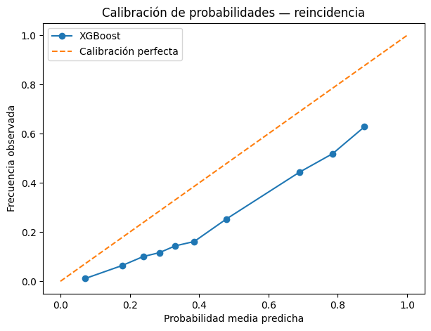

```
Archivo guardado: /content/TFM_INSPECCIONES/resultados/feature_importance_recurrence.csv
Filas: 210
Columnas: 2
```

|  | feature_transformed | importance |
| --- | --- | --- |
| 182 | cat__grade_not_rated | 0.111559 |
| 183 | cat__grade_okay | 0.105182 |
| 180 | cat__grade_good | 0.092819 |
| 178 | cat__seating_range_not_applicable | 0.056042 |
| 179 | cat__grade_excellent | 0.046980 |
| 204 | num__has_red_violation | 0.041183 |
| 187 | num__violation_points | 0.024324 |
| 190 | num__current_unsatisfactory | 0.019812 |
| 189 | num__risk_category | 0.017623 |
| 11 | cat__classification_school lunch program | 0.012266 |
| 170 | cat__inspection_type_return inspection | 0.010737 |
| 108 | cat__zip_code_98057 | 0.010495 |
| 5 | cat__classification_general food services | 0.008799 |
| 196 | num__previous_avg_violation_points | 0.008674 |
| 181 | cat__grade_needs to improve | 0.008536 |
| 209 | num__inspection_year | 0.007482 |
| 188 | num__number_violations | 0.007393 |
| 130 | cat__zip_code_98116 | 0.005997 |
| 135 | cat__zip_code_98122 | 0.005874 |
| 77 | cat__zip_code_98007 | 0.005724 |

```
Archivo guardado: /content/TFM_INSPECCIONES/resultados/recurrence_predictions.csv
Filas: 59,770
Columnas: 12
```

|  | inspection_serial_num | business_id | name | inspection_date | classification | city | zip_code | inspection_result | next_inspection_date | days_to_next_inspection | probability_recurrence | risk_group |
| --- | --- | --- | --- | --- | --- | --- | --- | --- | --- | --- | --- | --- |
| 0 | pfe-damu1adcx | pfe-pr-3126712 | old fifth ave llc | 2021-06-23 | general food services | seattle | 98115 | satisfactory | 2022-05-03 | 314.0 | 0.496984 | Moderate |
| 1 | pfe-daxfcpa2p | pfe-pr-3126712 | old fifth ave llc | 2022-05-03 | general food services | seattle | 98115 | satisfactory | 2023-01-11 | 253.0 | 0.538554 | Moderate |
| 2 | pfe-da1n5mrx7 | pfe-pr-3126712 | old fifth ave llc | 2023-01-11 | general food services | seattle | 98115 | satisfactory | 2023-07-31 | 201.0 | 0.482117 | Moderate |
| 3 | pfe-dali0je1y | pfe-pr-3126712 | old fifth ave llc | 2023-07-31 | general food services | seattle | 98115 | satisfactory | 2024-01-31 | 184.0 | 0.445762 | Moderate |
| 4 | pfe-da8jzf9cc | pfe-pr-3126712 | old fifth ave llc | 2024-01-31 | general food services | seattle | 98115 | satisfactory | 2025-08-05 | 552.0 | 0.274561 | Low |
| 5 | pfe-da0iw0x0t | pfe-pr-3126712 | old fifth ave llc | 2025-08-05 | general food services | seattle | 98115 | satisfactory | 2026-02-23 | 202.0 | 0.270323 | Low |
| 7 | pfe-dag4v9gcn | pfe-pr-3126713 | zouave restaurant | 2021-03-30 | general food services | seattle | 98115 | unsatisfactory | 2022-08-09 | 497.0 | 0.945921 | Very High |
| 8 | pfe-da6mqfk4e | pfe-pr-3126713 | zouave restaurant | 2022-08-09 | general food services | seattle | 98115 | satisfactory | 2024-07-17 | 708.0 | 0.918604 | Very High |
| 9 | pfe-da3p0dgjr | pfe-pr-3126713 | zouave restaurant | 2024-07-17 | general food services | seattle | 98115 | unsatisfactory | 2024-08-06 | 20.0 | 0.511140 | Moderate |
| 10 | pfe-dasvyc8qv | pfe-pr-3126713 | zouave restaurant | 2024-08-06 | general food services | seattle | 98115 | satisfactory | 2025-06-17 | 315.0 | 0.912629 | Very High |
| 11 | pfe-dajanhnqs | pfe-pr-3126713 | zouave restaurant | 2025-06-17 | general food services | seattle | 98115 | unsatisfactory | 2025-07-01 | 14.0 | 0.530084 | Moderate |
| 12 | pfe-daug8o1ba | pfe-pr-3126713 | zouave restaurant | 2025-07-01 | general food services | seattle | 98115 | unsatisfactory | 2025-07-16 | 15.0 | 0.504268 | Moderate |
| 15 | pfe-dadwlvsup | pfe-pr-3126715 | 7-eleven store #2360-14373c | 2021-02-22 | general food services | seattle | 98115 | satisfactory | 2021-11-23 | 274.0 | 0.887224 | Very High |
| 16 | pfe-da4cvaes0 | pfe-pr-3126715 | 7-eleven store #2360-14373c | 2021-11-23 | general food services | seattle | 98115 | unsatisfactory | 2022-05-03 | 161.0 | 0.869323 | Very High |
| 17 | pfe-dahtr89om | pfe-pr-3126715 | 7-eleven store #2360-14373c | 2022-05-03 | general food services | seattle | 98115 | unsatisfactory | 2022-05-23 | 20.0 | 0.528879 | Moderate |
| 18 | pfe-dabmmrwfc | pfe-pr-3126715 | 7-eleven store #2360-14373c | 2022-05-23 | general food services | seattle | 98115 | unsatisfactory | 2022-06-02 | 10.0 | 0.425532 | Moderate |
| 19 | pfe-daxu2fgzx | pfe-pr-3126715 | 7-eleven store #2360-14373c | 2022-06-02 | general food services | seattle | 98115 | satisfactory | 2022-12-07 | 188.0 | 0.879275 | Very High |
| 20 | pfe-dakv0kg1t | pfe-pr-3126715 | 7-eleven store #2360-14373c | 2022-12-07 | general food services | seattle | 98115 | unsatisfactory | 2022-12-14 | 7.0 | 0.536575 | Moderate |
| 21 | pfe-da4hpadjn | pfe-pr-3126715 | 7-eleven store #2360-14373c | 2022-12-14 | general food services | seattle | 98115 | unsatisfactory | 2023-05-24 | 161.0 | 0.910356 | Very High |
| 22 | pfe-daf6hbmtb | pfe-pr-3126715 | 7-eleven store #2360-14373c | 2023-05-24 | general food services | seattle | 98115 | unsatisfactory | 2023-05-31 | 7.0 | 0.476545 | Moderate |

```
Archivo guardado: /content/TFM_INSPECCIONES/resultados/inspector_ranking.csv
Filas: 11,401
Columnas: 17
```

|  | business_id | name | classification | address | city | zip_code | probability_recurrence | risk_group | inspection_date | previous_result | previous_inspections | previous_unsatisfactory | previous_unsatisfactory_rate | unsat_last_3 | violations_last_3 | points_last_3 | points_trend_last_5 |
| --- | --- | --- | --- | --- | --- | --- | --- | --- | --- | --- | --- | --- | --- | --- | --- | --- | --- |
| 59548 | pfe-pr-3146940 | taste of xian bellevue llc | general food services | 14509 ne 20th st, d | bellevue | 98007 | 0.980546 | Very High | 2025-01-14 | unsatisfactory | 7 | 6 | 0.857143 | 3.0 | 19.0 | 139.0 | 5.900000e+00 |
| 50084 | pfe-pr-3144069 | tiger bites | general food services | 14701 ne 20th st, m12 | bellevue | 98007 | 0.974518 | Very High | 2025-09-10 | unsatisfactory | 13 | 9 | 0.692308 | 3.0 | 26.0 | 187.0 | 3.400000e+00 |
| 46947 | pfe-pr-3142913 | benjarong thai | general food services | 24061 se 264th st, m100 | maple valley | 98038 | 0.972737 | Very High | 2024-09-25 | unsatisfactory | 6 | 6 | 1.000000 | 3.0 | 15.0 | 188.0 | 1.570000e+01 |
| 15221 | pfe-pr-3131142 | grocery plus | general food services | 9660 16th ave sw | seattle | 98106 | 0.970778 | Very High | 2025-09-03 | unsatisfactory | 4 | 4 | 1.000000 | 3.0 | 24.0 | 191.0 | NaN |
| 18658 | pfe-pr-3132171 | madhurai mess | general food services | 1424 156th ave ne | bellevue | 98007 | 0.970329 | Very High | 2025-10-24 | unsatisfactory | 5 | 5 | 1.000000 | 3.0 | 19.0 | 151.0 | 5.000000e+00 |
| 63727 | pfe-pr-3148096 | circle chinese cuisine | general food services | 1734 central ave s | kent | 98032 | 0.969341 | Very High | 2025-04-21 | unsatisfactory | 4 | 4 | 1.000000 | 3.0 | 26.0 | 184.0 | NaN |
| 16056 | pfe-pr-3131369 | jot indian sweets & restaurant | general food services | 25445 104th ave se | kent | 98030 | 0.966085 | Very High | 2025-11-14 | unsatisfactory | 4 | 4 | 1.000000 | 3.0 | 23.0 | 169.0 | NaN |
| 49024 | pfe-pr-3143749 | saigon soul | general food services | 24202 104th ave se, 108 | kent | 98030 | 0.962971 | Very High | 2025-02-25 | unsatisfactory | 4 | 3 | 0.750000 | 3.0 | 28.0 | 240.0 | NaN |
| 14953 | pfe-pr-3131041 | lee's kitchen | general food services | 2409 152nd ave ne | redmond | 98052 | 0.961654 | Very High | 2025-08-13 | unsatisfactory | 3 | 3 | 1.000000 | 3.0 | 14.0 | 131.0 | NaN |
| 21820 | pfe-pr-3133264 | italio pizza & pasta | general food services | 305 nw 85th st | seattle | 98117 | 0.960561 | Very High | 2025-06-17 | satisfactory | 8 | 5 | 0.625000 | 2.0 | 12.0 | 80.0 | -1.900000e+00 |
| 14135 | pfe-pr-3130767 | jalisco restaurant | general food services | 12336 31st ave ne | seattle | 98125 | 0.960152 | Very High | 2025-03-26 | satisfactory | 5 | 3 | 0.600000 | 2.0 | 9.0 | 50.0 | 7.000000e-01 |
| 7864 | pfe-pr-3129026 | little garden chinese restaurant | general food services | 14725 ne 20th st | bellevue | 98007 | 0.959632 | Very High | 2024-09-03 | unsatisfactory | 3 | 2 | 0.666667 | 2.0 | 12.0 | 73.0 | NaN |
| 1100 | pfe-pr-3126994 | adulis eritrean & ethiopian restaurant | general food services | 10515 greenwood ave n | seattle | 98133 | 0.959629 | Very High | 2024-11-18 | unsatisfactory | 4 | 3 | 0.750000 | 2.0 | 7.0 | 40.0 | NaN |
| 29828 | pfe-pr-3135837 | hardware store great good food | general food services | 17601 vashon hwy sw | vashon island | 98070 | 0.959239 | Very High | 2024-06-28 | unsatisfactory | 4 | 3 | 0.750000 | 3.0 | 11.0 | 64.0 | NaN |
| 34256 | pfe-pr-3137594 | anjappar chettinad indian restaurant | general food services | 14625 ne 24th st | bellevue | 98007 | 0.959027 | Very High | 2025-07-17 | unsatisfactory | 12 | 10 | 0.833333 | 3.0 | 23.0 | 231.0 | 2.540000e+01 |
| 4838 | pfe-pr-3128137 | riverside casino inc. | general food services | 14060 interurban ave s | tukwila | 98168 | 0.958876 | Very High | 2024-08-23 | satisfactory | 3 | 2 | 0.666667 | 2.0 | 11.0 | 65.0 | NaN |
| 6577 | pfe-pr-3128608 | 7-eleven store #2360-14402d | general food services | 8316 164th ave ne | redmond | 98052 | 0.958522 | Very High | 2025-09-17 | unsatisfactory | 7 | 6 | 0.857143 | 3.0 | 7.0 | 42.0 | -1.100000e+00 |
| 37106 | pfe-pr-3138705 | tapioca express | general food services | 15230 ne 24th st, 1-r | redmond | 98052 | 0.958492 | Very High | 2025-02-21 | unsatisfactory | 7 | 6 | 0.857143 | 3.0 | 8.0 | 53.0 | 4.600000e+00 |
| 25522 | pfe-pr-3134447 | bel-red chevron | general food services | 2444 ne bel red rd | bellevue | 98007 | 0.958102 | Very High | 2024-10-18 | unsatisfactory | 6 | 5 | 0.833333 | 3.0 | 11.0 | 70.0 | -4.597351e-16 |
| 74 | pfe-pr-3126726 | sodhi holdings inc dba 7-eleven store #14396e | general food services | 7215 sandpoint way ne | seattle | 98115 | 0.957668 | Very High | 2024-04-24 | unsatisfactory | 10 | 10 | 1.000000 | 3.0 | 15.0 | 134.0 | 3.600000e+00 |

```
 Modelo de reincidencia terminado.
Mejor modelo: XGBoost
```

|  | model | roc_auc | average_precision | brier | accuracy_at_0_5 | positive_rate_test | n_train | n_test | problem |
| --- | --- | --- | --- | --- | --- | --- | --- | --- | --- |
| 0 | XGBoost | 0.798755 | 0.547904 | 0.182719 | 0.763677 | 0.244102 | 47816 | 11954 | reincidence |
| 1 | Random Forest | 0.797380 | 0.542332 | 0.165195 | 0.770788 | 0.244102 | 47816 | 11954 | reincidence |
| 2 | Extra Trees | 0.793111 | 0.538652 | 0.179220 | 0.745525 | 0.244102 | 47816 | 11954 | reincidence |

```python
# MODELO DE REINCIDENCIA


recurrence = train_recurrence_model(inspections)

print('\n Modelo de reincidencia terminado.')
print('Mejor modelo:', recurrence['best_name'])
display(recurrence['results'])
```

## Interpretar los resultados

El modelo elegido es el XGBoost, que es un mecanismo de boobsting basado en árboles que permite construir modelos predictivos eficientes mediante la combinación secuencial de árboles de decisión y que durante más de 10 años ha sido objeto de implementación con éxito para el análisis de dataset como el que presentamos (Chen, T., & Guestrin, C. (2016))

Por ello, será el que se utilice para entrenar el modelo de reincidencia.

Para visualizar los resultados y ponerlos a disposición de los inspectores, visualizamos y generamos el archivo de reincidencia, que luego será incorporado al dashboard para apoyar y facilitar la interpretación, como una herramienta útil para su trabajo.

```python
# Ver las predicciones de reincidencia
recurrence_predictions = pd.read_csv(OUTPUT_DIR / 'recurrence_predictions.csv')

print('Ejemplo de probabilidades:')
display(recurrence_predictions.head(10))

print('\nTop 20 por probabilidad de reincidencia:')
display(
    recurrence_predictions
    .sort_values('probability_recurrence', ascending=False)
    .head(20)
)
```

```
Ejemplo de probabilidades:
```

|  | inspection_serial_num | business_id | name | inspection_date | classification | city | zip_code | inspection_result | next_inspection_date | days_to_next_inspection | probability_recurrence | risk_group |
| --- | --- | --- | --- | --- | --- | --- | --- | --- | --- | --- | --- | --- |
| 0 | pfe-damu1adcx | pfe-pr-3126712 | old fifth ave llc | 2021-06-23 | general food services | seattle | 98115 | satisfactory | 2022-05-03 | 314.0 | 0.496984 | Moderate |
| 1 | pfe-daxfcpa2p | pfe-pr-3126712 | old fifth ave llc | 2022-05-03 | general food services | seattle | 98115 | satisfactory | 2023-01-11 | 253.0 | 0.538554 | Moderate |
| 2 | pfe-da1n5mrx7 | pfe-pr-3126712 | old fifth ave llc | 2023-01-11 | general food services | seattle | 98115 | satisfactory | 2023-07-31 | 201.0 | 0.482117 | Moderate |
| 3 | pfe-dali0je1y | pfe-pr-3126712 | old fifth ave llc | 2023-07-31 | general food services | seattle | 98115 | satisfactory | 2024-01-31 | 184.0 | 0.445762 | Moderate |
| 4 | pfe-da8jzf9cc | pfe-pr-3126712 | old fifth ave llc | 2024-01-31 | general food services | seattle | 98115 | satisfactory | 2025-08-05 | 552.0 | 0.274561 | Low |
| 5 | pfe-da0iw0x0t | pfe-pr-3126712 | old fifth ave llc | 2025-08-05 | general food services | seattle | 98115 | satisfactory | 2026-02-23 | 202.0 | 0.270323 | Low |
| 6 | pfe-dag4v9gcn | pfe-pr-3126713 | zouave restaurant | 2021-03-30 | general food services | seattle | 98115 | unsatisfactory | 2022-08-09 | 497.0 | 0.945921 | Very High |
| 7 | pfe-da6mqfk4e | pfe-pr-3126713 | zouave restaurant | 2022-08-09 | general food services | seattle | 98115 | satisfactory | 2024-07-17 | 708.0 | 0.918604 | Very High |
| 8 | pfe-da3p0dgjr | pfe-pr-3126713 | zouave restaurant | 2024-07-17 | general food services | seattle | 98115 | unsatisfactory | 2024-08-06 | 20.0 | 0.511140 | Moderate |
| 9 | pfe-dasvyc8qv | pfe-pr-3126713 | zouave restaurant | 2024-08-06 | general food services | seattle | 98115 | satisfactory | 2025-06-17 | 315.0 | 0.912629 | Very High |

```
Top 20 por probabilidad de reincidencia:
```

|  | inspection_serial_num | business_id | name | inspection_date | classification | city | zip_code | inspection_result | next_inspection_date | days_to_next_inspection | probability_recurrence | risk_group |
| --- | --- | --- | --- | --- | --- | --- | --- | --- | --- | --- | --- | --- |
| 46405 | pfe-da7y9mg3s | pfe-pr-3145493 | tian fu | 2024-04-08 | general food services | seattle | 98125 | unsatisfactory | 2024-11-05 | 211.0 | 0.982502 | Very High |
| 50503 | pfe-darkq1yjr | pfe-pr-3146940 | taste of xian bellevue llc | 2025-01-14 | general food services | bellevue | 98007 | unsatisfactory | 2025-11-20 | 310.0 | 0.980546 | Very High |
| 50502 | pfe-dapejhxrg | pfe-pr-3146940 | taste of xian bellevue llc | 2024-02-27 | general food services | bellevue | 98007 | unsatisfactory | 2025-01-14 | 322.0 | 0.975992 | Very High |
| 40806 | pfe-dalgkxgaz | pfe-pr-3143306 | tasty szechuan | 2024-01-05 | general food services | bellevue | 98007 | unsatisfactory | 2025-01-15 | 376.0 | 0.975814 | Very High |
| 42587 | pfe-daxr37xnf | pfe-pr-3144069 | tiger bites | 2024-04-12 | general food services | bellevue | 98007 | satisfactory | 2024-10-09 | 180.0 | 0.975050 | Very High |
| 29694 | pfe-da3kmgnwb | pfe-pr-3137791 | pho 7 | 2023-03-16 | general food services | kent | 98030 | satisfactory | 2024-04-04 | 385.0 | 0.975020 | Very High |
| 52737 | pfe-das1ywytc | pfe-pr-3147662 | spicy popo szechuan fish | 2024-09-13 | general food services | bellevue | 98007 | unsatisfactory | 2025-02-07 | 147.0 | 0.974618 | Very High |
| 42591 | pfe-dasvtjp8x | pfe-pr-3144069 | tiger bites | 2025-09-10 | general food services | bellevue | 98007 | satisfactory | 2026-04-01 | 203.0 | 0.974518 | Very High |
| 2830 | pfe-davfrimcu | pfe-pr-3127686 | red onion tavern | 2024-10-24 | general food services | seattle | 98112 | unsatisfactory | 2025-03-11 | 138.0 | 0.973493 | Very High |
| 39950 | pfe-damm3ccsn | pfe-pr-3142913 | benjarong thai | 2024-09-25 | general food services | maple valley | 98038 | unsatisfactory | 2025-09-16 | 356.0 | 0.972737 | Very High |
| 27256 | pfe-daz9vdk9q | pfe-pr-3136673 | kimchi house | 2024-02-22 | general food services | seattle | 98107 | unsatisfactory | 2024-10-10 | 231.0 | 0.972299 | Very High |
| 665 | pfe-dallqxtp0 | pfe-pr-3126916 | ballard mandarin chinese restaurant | 2023-03-27 | general food services | seattle | 98107 | unsatisfactory | 2024-02-05 | 315.0 | 0.972028 | Very High |
| 24232 | pfe-dakeb7fcf | pfe-pr-3135463 | palermo pizza & pasta | 2023-03-17 | general food services | seattle | 98112 | satisfactory | 2024-02-27 | 347.0 | 0.971594 | Very High |
| 13014 | pfe-daone3wxy | pfe-pr-3131142 | grocery plus | 2025-09-03 | general food services | seattle | 98106 | satisfactory | 2026-04-23 | 232.0 | 0.970778 | Very High |
| 15317 | pfe-da51friic | pfe-pr-3131913 | monsoon | 2024-01-04 | general food services | seattle | 98112 | unsatisfactory | 2024-08-07 | 216.0 | 0.970555 | Very High |
| 15957 | pfe-dapakg0zx | pfe-pr-3132171 | madhurai mess | 2025-10-24 | general food services | bellevue | 98007 | unsatisfactory | 2026-03-20 | 147.0 | 0.970329 | Very High |
| 53992 | pfe-darglpqad | pfe-pr-3148096 | circle chinese cuisine | 2025-04-21 | general food services | kent | 98032 | satisfactory | 2026-07-30 | 465.0 | 0.969341 | Very High |
| 46407 | pfe-daqrj4gft | pfe-pr-3145493 | tian fu | 2025-05-13 | general food services | seattle | 98125 | unsatisfactory | 2025-09-12 | 122.0 | 0.969337 | Very High |
| 6302 | pfe-daprwhf8k | pfe-pr-3128874 | ruchi indian restaurant | 2023-07-20 | general food services | bellevue | 98007 | unsatisfactory | 2024-02-21 | 216.0 | 0.969091 | Very High |
| 15955 | pfe-daggcib0q | pfe-pr-3132171 | madhurai mess | 2025-03-12 | general food services | bellevue | 98007 | unsatisfactory | 2025-10-01 | 203.0 | 0.969016 | Very High |

## Primera inspección.

Pero si hasta aquí hemos partido de que existen datos previos sobre un establecimiento, y medimos la reincidencia, el siguiente paso es entrenar al modelo para predecir, en aquellos supuestos en los que no hay información sobre el establecimiento en concreto, cuál va a ser el resultado de la inspección. Como no disponemos de historial previso, se utiliza únicamente información que puede conocerse antes de la inspección, como clasificación, ciudad, ZIP, tipo de inspección, aforo y categoría de riesgo.

```
================================================================================
4. MODELO DE PRIMERA INSPECCIÓN
================================================================================
           model  roc_auc  average_precision   brier  accuracy_at_0_5  \
0  Random Forest   0.6069             0.2770  0.2436           0.5874
1        XGBoost   0.6096             0.2765  0.2485           0.5488
2    Extra Trees   0.5998             0.2677  0.2535           0.5744

   positive_rate_test  n_train  n_test           problem
0              0.2159     9839    2460  first_inspection
1              0.2159     9839    2460  first_inspection
2              0.2159     9839    2460  first_inspection
Mejor modelo primera inspección: Random Forest
```

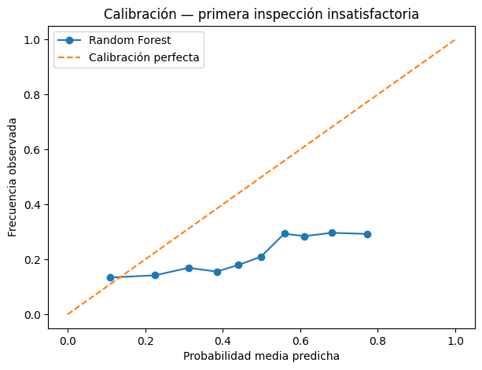

```
Archivo guardado: /content/TFM_INSPECCIONES/resultados/model_comparison_first_inspection.csv
Filas: 3
Columnas: 9
```

|  | model | roc_auc | average_precision | brier | accuracy_at_0_5 | positive_rate_test | n_train | n_test | problem |
| --- | --- | --- | --- | --- | --- | --- | --- | --- | --- |
| 0 | Random Forest | 0.606912 | 0.276993 | 0.243593 | 0.587398 | 0.215854 | 9839 | 2460 | first_inspection |
| 1 | XGBoost | 0.609644 | 0.276507 | 0.248538 | 0.548780 | 0.215854 | 9839 | 2460 | first_inspection |
| 2 | Extra Trees | 0.599798 | 0.267721 | 0.253499 | 0.574390 | 0.215854 | 9839 | 2460 | first_inspection |

```
Archivo guardado: /content/TFM_INSPECCIONES/resultados/first_inspection_predictions.csv
Filas: 12,299
Columnas: 12
```

|  | business_id | name | classification | city | zip_code | inspection_type | seating_range | risk_category | inspection_date | inspection_result | probability_first_inspection_unsatisfactory | risk_group |
| --- | --- | --- | --- | --- | --- | --- | --- | --- | --- | --- | --- | --- |
| 0 | pfe-pr-3126712 | old fifth ave llc | general food services | seattle | 98115 | routine inspection/field review | 13-50 | 3.0 | 2021-06-23 | satisfactory | 0.665541 | High |
| 7 | pfe-pr-3126713 | zouave restaurant | general food services | seattle | 98115 | routine inspection/field review | 13-50 | 3.0 | 2021-03-30 | unsatisfactory | 0.665541 | High |
| 14 | pfe-pr-3126714 | 7-eleven store #14355a | general food services | seattle | 98115 | routine inspection/field review | 0-12 | 3.0 | 2025-11-19 | satisfactory | 0.563627 | Moderate |
| 15 | pfe-pr-3126715 | 7-eleven store #2360-14373c | general food services | seattle | 98115 | routine inspection/field review | 0-12 | 3.0 | 2021-02-22 | satisfactory | 0.563627 | Moderate |
| 29 | pfe-pr-3126716 | 7-eleven store #2360-14360a | general food services | seattle | 98107 | routine inspection/field review | 0-12 | 3.0 | 2022-02-18 | satisfactory | 0.524191 | Moderate |
| 36 | pfe-pr-3126718 | 7-eleven #16022g | general food services | seattle | 98103 | routine inspection/field review | 0-12 | 3.0 | 2022-10-19 | satisfactory | 0.343733 | Low |
| 42 | pfe-pr-3126720 | the local 104 | general food services | lake forest park | 98155 | routine inspection/field review | 51-150 | 3.0 | 2021-04-28 | satisfactory | 0.616104 | High |
| 48 | pfe-pr-3126721 | 7-eleven #16365f | general food services | seattle | 98107 | routine inspection/field review | 0-12 | 3.0 | 2025-04-17 | unsatisfactory | 0.524191 | Moderate |
| 50 | pfe-pr-3126723 | 7-eleven store #22625d | general food services | shoreline | 98155 | routine inspection/field review | 0-12 | 3.0 | 2021-01-04 | unsatisfactory | 0.695484 | High |
| 61 | pfe-pr-3126725 | 7-eleven store #14354d | general food services | shoreline | 98155 | routine inspection/field review | 0-12 | 3.0 | 2024-11-18 | unsatisfactory | 0.695484 | High |
| 64 | pfe-pr-3126726 | sodhi holdings inc dba 7-eleven store #14396e | general food services | seattle | 98115 | routine inspection/field review | 0-12 | 3.0 | 2021-10-18 | unsatisfactory | 0.563627 | Moderate |
| 76 | pfe-pr-3126727 | 7-eleven #18553e | general food services | seattle | 98103 | routine inspection/field review | 0-12 | 3.0 | 2023-06-21 | satisfactory | 0.343733 | Low |
| 82 | pfe-pr-3126729 | jai thai | general food services | seattle | 98103 | routine inspection/field review | 51-150 | 3.0 | 2026-02-25 | satisfactory | 0.589915 | Moderate |
| 83 | pfe-pr-3126730 | adams elementary school | school lunch program | seattle | 98107 | routine inspection/field review | not_applicable | 3.0 | 2021-10-20 | satisfactory | 0.217652 | Low |
| 93 | pfe-pr-3126731 | al's tavern | general food services | seattle | 98103 | routine inspection/field review | 13-50 | 2.0 | 2022-10-27 | satisfactory | 0.324977 | Low |
| 98 | pfe-pr-3126735 | albertsons #3416 | bakery | lake forest park | 98155 | routine inspection/field review | not_applicable | 2.0 | 2021-01-11 | satisfactory | 0.304315 | Low |
| 103 | pfe-pr-3126736 | albertsons #3416 | grocery store | lake forest park | 98155 | routine inspection/field review | not_applicable | 2.0 | 2021-01-11 | satisfactory | 0.611734 | High |
| 108 | pfe-pr-3126742 | allegro espresso bar | general food services | seattle | 98105 | routine inspection/field review | 13-50 | 1.0 | 2022-06-13 | satisfactory | 0.185887 | Low |
| 112 | pfe-pr-3126743 | alpha chi omega | general food services | seattle | 98105 | routine inspection/field review | 51-150 | 3.0 | 2021-11-03 | unsatisfactory | 0.746508 | Very High |
| 119 | pfe-pr-3126745 | alpha delta pi | general food services | seattle | 98105 | routine inspection/field review | 151-250 | 3.0 | 2021-11-08 | satisfactory | 0.644293 | High |

```python
# MODELO PARA UNA PRIMERA INSPECCIÓN


first_model = train_first_inspection_model(inspections)
```

Aquí los resultados empeoran, ya que no se dispone de los antecedentes que en el caso anterior, y así deberá advertirse a los inspectores, pues a continuación veremos gráficamente cómo ese mapa de riesgo hace que resulte complejo

## Riesgo por ciudad, tipo de establecimiento y otras variables

Pero tan importante como los datos lo son las visualizacions y las tablas que se generan pues las mismas sirven de ayuda interpretativa de los datos. Aquí reflejamos:

- Qué tipos de establecimientos tienen mayor riesgo.
- Qué ciudades presentanmayor riesgo.
- Combinación tipos de establecimiento y ciudad.
- Distribución de las probabilidades que nos ha fijado el modelo según el modelo de tiempo escogido según los inervalos que hemos referido.

Esta orientación de la investigación basada en el análisis de riesgos y en la planificación de los recursos ha venido siendo avalada por la FAO (2008, 2026), que desde hace casi 20 años ha venido abogando por este plateamiento insistiendo en la relevancia de la evaluación de riesgos y la colaboración entre la administración y los gestores se convierte en clave para la minimización de los riesgos, en el bien entendido que sus recomendaciones, aunque orientadas enprincipio a países en desarrollo, resultan perfectamente extrapolables para los criterios y principios que se han seguido de cara a la elaboración del análisis. En las celdas siguientes se muestran esos resultados, que también se han generado en formato csv para facilitar su tratamiento posterior.

En el bien entendido que todas y cada una de estas representaciones o cálculos no deben interpretarse como verdades absolutas, sino como una proyección o una potencial advertencia hecha con la información disponible hasta la fecha, y de ahí la importancia de mantener y alimentar la tabla que se usa como fuente.

```
================================================================================
RIESGO POR TIPOLOGÍA, CIUDAD Y UBICACIÓN
================================================================================

Archivo guardado: /content/TFM_INSPECCIONES/resultados/classification_risk.csv
Filas: 12
Columnas: 6
```

|  | classification | inspections | businesses | reincidences | recurrence_rate | smoothed_rate |
| --- | --- | --- | --- | --- | --- | --- |
| 5 | general food services | 44102 | 8265 | 15210 | 0.344882 | 0.344865 |
| 9 | mobile food unit | 2060 | 557 | 702 | 0.340777 | 0.340459 |
| 1 | bed and breakfast operation | 11 | 4 | 3 | 0.272727 | 0.295331 |
| 8 | meat/fish market | 2586 | 379 | 697 | 0.269528 | 0.269822 |
| 4 | dfdo exempt from billing | 35 | 4 | 8 | 0.228571 | 0.257368 |
| 10 | nonprofit institution | 1287 | 269 | 276 | 0.214452 | 0.215880 |
| 7 | limited food service | 328 | 97 | 65 | 0.198171 | 0.204469 |
| 6 | grocery store | 3443 | 878 | 698 | 0.202730 | 0.203337 |
| 2 | catering operation | 868 | 246 | 174 | 0.200461 | 0.202878 |
| 3 | commissary kitchen | 23 | 14 | 2 | 0.086957 | 0.189657 |
| 0 | bakery | 1023 | 223 | 143 | 0.139785 | 0.143006 |
| 11 | school lunch program | 4004 | 465 | 417 | 0.104146 | 0.105158 |

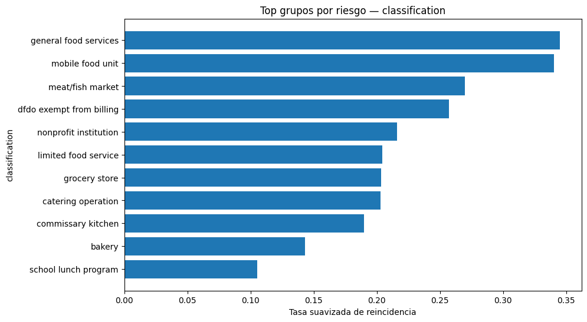

```
export_plot
def export_plot(fig, path)
```

```
/tmp/ipykernel_1037/816432270.py<no docstring>
```

```
Archivo guardado: /content/TFM_INSPECCIONES/resultados/city_risk.csv
Filas: 61
Columnas: 6
```

|  | city | inspections | businesses | reincidences | recurrence_rate | smoothed_rate |
| --- | --- | --- | --- | --- | --- | --- |
| 39 | preston | 17 | 3 | 13 | 0.764706 | 0.517710 |
| 58 | vashon island | 215 | 46 | 100 | 0.465116 | 0.451725 |
| 4 | belleue | 3 | 1 | 3 | 1.000000 | 0.398055 |
| 5 | bellevue | 3639 | 796 | 1403 | 0.385545 | 0.385120 |
| 55 | tacoma | 9 | 3 | 5 | 0.555556 | 0.384664 |
| 52 | snoqualmie | 412 | 76 | 159 | 0.385922 | 0.382304 |
| 48 | seattle, | 4 | 1 | 3 | 0.750000 | 0.381469 |
| 12 | covington | 426 | 74 | 157 | 0.368545 | 0.365819 |
| 23 | kent | 3081 | 574 | 1116 | 0.362220 | 0.361869 |
| 27 | maple valley | 661 | 106 | 235 | 0.355522 | 0.354119 |
| 45 | sea tac | 140 | 27 | 49 | 0.350000 | 0.344720 |
| 56 | tukwila | 1528 | 317 | 525 | 0.343586 | 0.343124 |
| 13 | des moines | 533 | 91 | 181 | 0.339587 | 0.338436 |
| 22 | kenmore | 292 | 56 | 98 | 0.335616 | 0.333831 |
| 21 | issaquah | 1040 | 229 | 344 | 0.330769 | 0.330335 |
| 1 | aberdeen | 5 | 1 | 2 | 0.400000 | 0.326210 |
| 26 | lynnwood | 5 | 1 | 2 | 0.400000 | 0.326210 |
| 47 | seattle | 27344 | 5173 | 8897 | 0.325373 | 0.325360 |
| 25 | lake forest park | 151 | 28 | 49 | 0.324503 | 0.322545 |
| 57 | vashon | 9 | 3 | 3 | 0.333333 | 0.315699 |

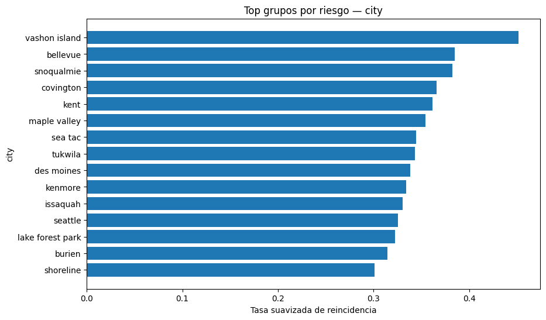

```
export_plot
def export_plot(fig, path)
```

```
/tmp/ipykernel_1037/816432270.py<no docstring>
```

```
Archivo guardado: /content/TFM_INSPECCIONES/resultados/zip_risk.csv
Filas: 100
Columnas: 6
```

|  | zip_code | inspections | businesses | reincidences | recurrence_rate | smoothed_rate |
| --- | --- | --- | --- | --- | --- | --- |
| 6 | 98007 | 814 | 162 | 426 | 0.523342 | 0.518172 |
| 31 | 98050 | 17 | 3 | 13 | 0.764706 | 0.517710 |
| 19 | 98030 | 534 | 125 | 278 | 0.520599 | 0.512916 |
| 36 | 98056 | 518 | 95 | 260 | 0.501931 | 0.494712 |
| 57 | 98112 | 629 | 109 | 308 | 0.489666 | 0.484060 |
| 20 | 98031 | 333 | 83 | 157 | 0.471471 | 0.462196 |
| 42 | 98070 | 224 | 49 | 103 | 0.459821 | 0.447358 |
| 55 | 98108 | 834 | 165 | 372 | 0.446043 | 0.442805 |
| 53 | 98106 | 506 | 110 | 224 | 0.442688 | 0.437558 |
| 61 | 98118 | 1526 | 223 | 639 | 0.418742 | 0.417306 |
| 77 | 98168 | 901 | 197 | 377 | 0.418424 | 0.416021 |
| 35 | 98055 | 227 | 39 | 96 | 0.422907 | 0.413584 |
| 97 | 98444 | 7 | 2 | 5 | 0.714286 | 0.413158 |
| 52 | 98105 | 1714 | 327 | 704 | 0.410735 | 0.409547 |
| 58 | 98115 | 1060 | 185 | 435 | 0.410377 | 0.408477 |
| 71 | 98146 | 416 | 76 | 168 | 0.403846 | 0.399439 |
| 49 | 98102 | 599 | 133 | 234 | 0.390651 | 0.387973 |
| 40 | 98065 | 412 | 76 | 159 | 0.385922 | 0.382304 |
| 18 | 98029 | 348 | 67 | 134 | 0.385057 | 0.380857 |
| 64 | 98122 | 1845 | 365 | 704 | 0.381572 | 0.380780 |

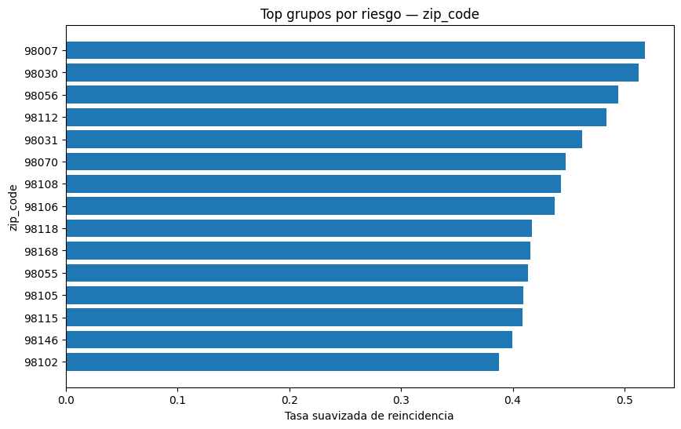

```
export_plot
def export_plot(fig, path)
```

```
/tmp/ipykernel_1037/816432270.py<no docstring>
```

```
Archivo guardado: /content/TFM_INSPECCIONES/resultados/classification_city_risk.csv
Filas: 163
Columnas: 7
```

|  | classification | city | inspections | businesses | reincidences | recurrence_rate | smoothed_rate |
| --- | --- | --- | --- | --- | --- | --- | --- |
| 200 | meat/fish market | tukwila | 47 | 8 | 32 | 0.680851 | 0.569482 |
| 108 | general food services | vashon island | 143 | 32 | 76 | 0.531469 | 0.504020 |
| 70 | general food services | bellevue | 2737 | 606 | 1214 | 0.443551 | 0.442566 |
| 102 | general food services | shoreline | 626 | 124 | 271 | 0.432907 | 0.429033 |
| 87 | general food services | maple valley | 460 | 76 | 198 | 0.430435 | 0.425323 |
| 77 | general food services | des moines | 357 | 64 | 154 | 0.431373 | 0.424815 |
| 76 | general food services | covington | 298 | 49 | 127 | 0.426174 | 0.418727 |
| 83 | general food services | kenmore | 185 | 36 | 79 | 0.427027 | 0.415392 |
| 165 | limited food service | renton | 24 | 6 | 12 | 0.500000 | 0.412620 |
| 84 | general food services | kent | 2257 | 391 | 918 | 0.406735 | 0.405865 |
| 241 | mobile food unit | tukwila | 163 | 47 | 68 | 0.417178 | 0.405220 |
| 82 | general food services | issaquah | 738 | 169 | 297 | 0.402439 | 0.399941 |
| 104 | general food services | snoqualmie | 284 | 55 | 115 | 0.404930 | 0.398537 |
| 86 | general food services | lake forest park | 91 | 17 | 38 | 0.417582 | 0.397795 |
| 98 | general food services | sea tac | 110 | 21 | 44 | 0.400000 | 0.385810 |
| 185 | meat/fish market | kent | 187 | 31 | 73 | 0.390374 | 0.382393 |
| 209 | mobile food unit | burien | 54 | 14 | 22 | 0.407407 | 0.380477 |
| 273 | nonprofit institution | snoqualmie | 36 | 5 | 15 | 0.416667 | 0.377773 |
| 71 | general food services | black diamond | 60 | 15 | 24 | 0.400000 | 0.376941 |
| 220 | mobile food unit | kirkland | 56 | 17 | 22 | 0.392857 | 0.370464 |

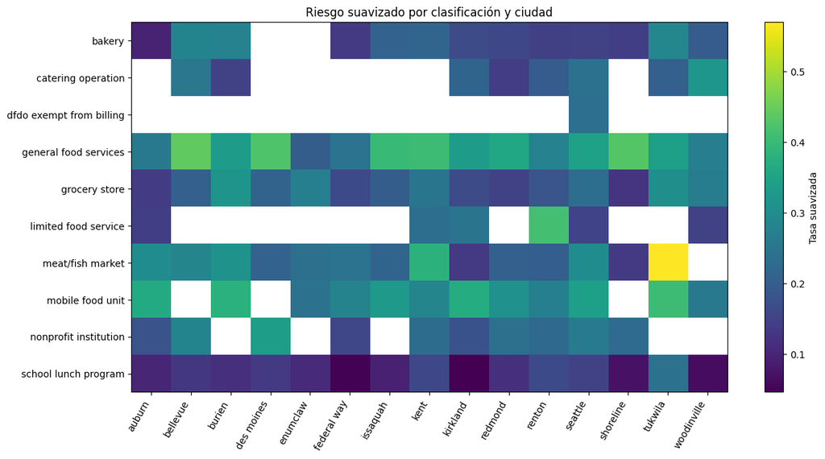

```
export_plot
def export_plot(fig, path)
```

```
/tmp/ipykernel_1037/816432270.py<no docstring>
```

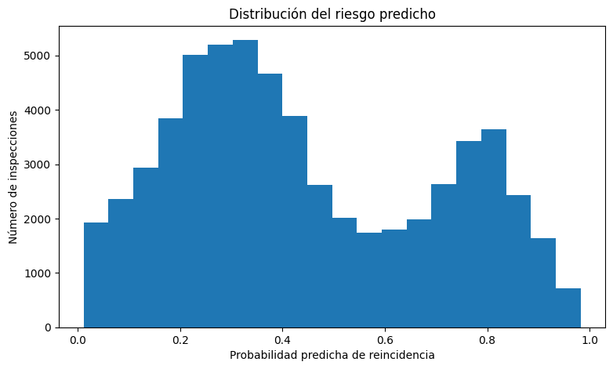

```
export_plot
def export_plot(fig, path)
```

```
/tmp/ipykernel_1037/816432270.py<no docstring>
```

```
Tablas y gráficos de riesgo creados.
```

```python
def risk_tables_and_plots(inspections, recurrence):
    print("\n" + "=" * 80)
    print("RIESGO POR TIPOLOGÍA, CIUDAD Y UBICACIÓN")
    print("=" * 80)

    model_base = recurrence["model_base"]
    scored = (
        model_base.assign(
            predicted_probability=recurrence["best_model"].predict_proba(
                model_base[recurrence["categorical"] + recurrence["numeric"]]
            )[:, 1]
        )
    )

    global_rate = scored["reincidence"].mean()

    tables = {}
    for col, filename in [
        ("classification", "classification_risk.csv"),
        ("city", "city_risk.csv"),
        ("zip_code", "zip_risk.csv"),
    ]:
        t = aggregate_risk(scored, [col])
        t = smoothed_rates(
            t, "reincidences", "inspections", global_rate, prior_strength=20
        )
        t = t.sort_values("smoothed_rate", ascending=False)

        export_table(t, OUTPUT_DIR / filename)

        plot = t[t["inspections"] >= MIN_GROUP_SIZE].head(15).copy()
        if not plot.empty:
            fig, ax = plt.subplots(figsize=(10, 6))
            ax.barh(
                plot[col].astype(str).iloc[::-1],
                plot["smoothed_rate"].iloc[::-1]
            )
            ax.set_xlabel("Tasa suavizada de reincidencia")
            ax.set_ylabel(col)
            ax.set_title(f"Top grupos por riesgo — {col}")
            export_plot(fig, OUTPUT_DIR / f"risk_{col}.png")
            display(export_plot)

    # Combinación clasificación + ciudad.
    cc = aggregate_risk(scored, ["classification", "city"])
    cc = smoothed_rates(
        cc, "reincidences", "inspections", global_rate, prior_strength=20
    )
    cc = cc[cc["inspections"] >= MIN_GROUP_SIZE].sort_values(
        "smoothed_rate", ascending=False
    )
    export_table( cc, OUTPUT_DIR / "classification_city_risk.csv")

    # Heatmap sin seaborn: pivot + imshow.
    top_classes = cc["classification"].value_counts().head(10).index
    top_cities = cc["city"].value_counts().head(15).index
    heat = cc[
        cc["classification"].isin(top_classes)
        & cc["city"].isin(top_cities)
    ].pivot_table(
        index="classification",
        columns="city",
        values="smoothed_rate",
        aggfunc="mean"
    )

    if not heat.empty:
        fig, ax = plt.subplots(figsize=(14, 7))
        im = ax.imshow(heat.values, aspect="auto")
        ax.set_xticks(range(len(heat.columns)))
        ax.set_xticklabels(heat.columns, rotation=60, ha="right")
        ax.set_yticks(range(len(heat.index)))
        ax.set_yticklabels(heat.index)
        ax.set_title("Riesgo suavizado por clasificación y ciudad")
        fig.colorbar(im, ax=ax, label="Tasa suavizada")
        export_plot(fig, OUTPUT_DIR / "heatmap_classification_city_risk.png")
        display(export_plot)

    # Distribución de probabilidad.
    fig, ax = plt.subplots(figsize=(9, 5))
    ax.hist(scored["predicted_probability"], bins=20)
    ax.set_xlabel("Probabilidad predicha de reincidencia")
    ax.set_ylabel("Número de inspecciones")
    ax.set_title("Distribución del riesgo predicho")
    export_plot(fig, OUTPUT_DIR / "distribution_predicted_recurrence.png")
    display(export_plot)

    return tables, scored


def optimize_inspection_interval(recurrence):

    print("\n" + "=" * 80)
    print("OPTIMIZACIÓN ORIENTATIVA DEL INTERVALO")
    print("=" * 80)

    model_base = recurrence["model_base"].copy()
    model = recurrence["best_model"]
    cats = recurrence["categorical"]
    nums = recurrence["numeric"]

    # Solo usamos filas con historial previo suficiente para que el intervalo
    # tenga sentido operativo.
    eligible = model_base[
        model_base["previous_inspections"] >= 1
    ].copy()

    if eligible.empty:
        print("No hay suficientes observaciones para optimizar intervalo.")
        return pd.DataFrame()

    rows = []
    for days in INTERVAL_CANDIDATES:
        scenario = eligible.copy()
        scenario["planned_days_to_next"] = days

        # El modelo espera las mismas columnas.
        X_s = scenario[cats + nums]
        p = model.predict_proba(X_s)[:, 1]

        rows.append({
            "planned_interval_days": days,
            "planned_interval_months": days / 30.4375,
            "mean_predicted_unsatisfactory_probability": p.mean(),
            "median_predicted_probability": np.median(p),
            "p90_predicted_probability": np.quantile(p, 0.90),
            "n_establishments_scored": len(scenario)
        })

    interval_df = pd.DataFrame(rows)
    interval_df.to_csv(
        OUTPUT_DIR / "optimal_inspection_interval.csv", index=False
    )

    best = interval_df.loc[
        interval_df["mean_predicted_unsatisfactory_probability"].idxmin()
    ]

    print(
        "Intervalo de menor riesgo predicho:",
        int(best["planned_interval_days"]),
        "días (aprox.",
        round(best["planned_interval_months"], 1),
        "meses)"
    )

    fig, ax = plt.subplots(figsize=(10, 5))
    ax.plot(
        interval_df["planned_interval_days"],
        interval_df["mean_predicted_unsatisfactory_probability"],
        marker="o"
    )
    ax.axvline(
        best["planned_interval_days"],
        linestyle="--",
        label="Mínimo predicho"
    )
    ax.set_xlabel("Intervalo planificado (días)")
    ax.set_ylabel("Probabilidad media predicha de siguiente inspección insatisfactoria")
    ax.set_title("Riesgo predicho según intervalo entre inspecciones")
    ax.legend()
    export_plot(fig, OUTPUT_DIR / "optimal_inspection_interval.png")

    return interval_df


risk_tables, scored = risk_tables_and_plots(inspections, recurrence)

print('Tablas y gráficos de riesgo creados.')

for key, table in risk_tables.items():
    print(f'\n--- {key} ---')
    display(table.head(15))
```

## Intervalo óptimo entre inspecciones

El análisis compara distintos intervalos candidatos (30, 60, 90... días) y utiliza el modelo para estimar el riesgo asociado.

```
================================================================================
OPTIMIZACIÓN ORIENTATIVA DEL INTERVALO
================================================================================
Intervalo de menor riesgo predicho: 30 días (aprox. 1.0 meses)
```

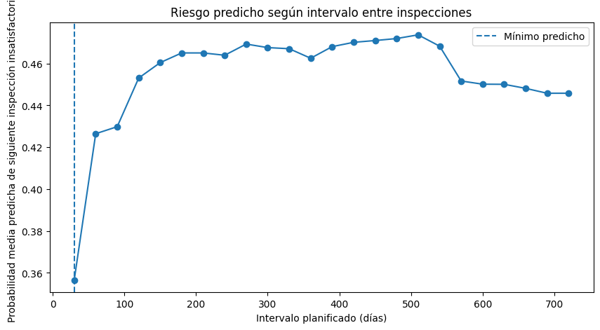

```
 Análisis del intervalo terminado.
```

|  | planned_interval_days | planned_interval_months | mean_predicted_unsatisfactory_probability | median_predicted_probability | p90_predicted_probability | n_establishments_scored |
| --- | --- | --- | --- | --- | --- | --- |
| 0 | 30 | 0.985626 | 0.356563 | 0.337987 | 0.598903 | 48369 |
| 1 | 60 | 1.971253 | 0.426471 | 0.362480 | 0.787513 | 48369 |
| 2 | 90 | 2.956879 | 0.429822 | 0.356636 | 0.814369 | 48369 |
| 3 | 120 | 3.942505 | 0.453066 | 0.380377 | 0.840549 | 48369 |
| 4 | 150 | 4.928131 | 0.460425 | 0.390426 | 0.842881 | 48369 |
| 5 | 180 | 5.913758 | 0.465053 | 0.398272 | 0.843666 | 48369 |
| 6 | 210 | 6.899384 | 0.465048 | 0.399041 | 0.844762 | 48369 |
| 7 | 240 | 7.885010 | 0.463945 | 0.401131 | 0.845259 | 48369 |
| 8 | 270 | 8.870637 | 0.469287 | 0.407835 | 0.848923 | 48369 |
| 9 | 300 | 9.856263 | 0.467603 | 0.402843 | 0.847786 | 48369 |
| 10 | 330 | 10.841889 | 0.467072 | 0.402492 | 0.847088 | 48369 |
| 11 | 360 | 11.827515 | 0.462519 | 0.393703 | 0.843223 | 48369 |
| 12 | 390 | 12.813142 | 0.468062 | 0.399168 | 0.845101 | 48369 |
| 13 | 420 | 13.798768 | 0.470126 | 0.398643 | 0.847763 | 48369 |
| 14 | 450 | 14.784394 | 0.470973 | 0.399690 | 0.848651 | 48369 |
| 15 | 480 | 15.770021 | 0.471931 | 0.400469 | 0.849086 | 48369 |
| 16 | 510 | 16.755647 | 0.473696 | 0.400332 | 0.851794 | 48369 |
| 17 | 540 | 17.741273 | 0.468279 | 0.394033 | 0.844914 | 48369 |
| 18 | 570 | 18.726899 | 0.451653 | 0.371521 | 0.820313 | 48369 |
| 19 | 600 | 19.712526 | 0.450127 | 0.369523 | 0.818133 | 48369 |
| 20 | 630 | 20.698152 | 0.450066 | 0.369468 | 0.818119 | 48369 |
| 21 | 660 | 21.683778 | 0.448129 | 0.366849 | 0.816971 | 48369 |
| 22 | 690 | 22.669405 | 0.445797 | 0.364062 | 0.817007 | 48369 |
| 23 | 720 | 23.655031 | 0.445797 | 0.364062 | 0.817007 | 48369 |

```
Intervalo con menor probabilidad media predicha: 30 días
```

```python
interval_df = optimize_inspection_interval(recurrence)

print(' Análisis del intervalo terminado.')
display(interval_df)

if not interval_df.empty:
    best_interval = interval_df.loc[
        interval_df['mean_predicted_unsatisfactory_probability'].idxmin()
    ]
    print(
        f"\nIntervalo con menor probabilidad media predicha: "
        f"{int(best_interval['planned_interval_days'])} días"
    )
```

## Tipología de violaciones

El análisis de las tipologías de violación se lleva a cabo sobre la tabla inicial, ya que de hacerlo a nivel de inspección se perdería buena parte de la información disponible. Aquí se muestra a los inspectores los resultados globales, calculando el total de puntos vulnerados en función de las infracciones efectivamente cometidas. Destacar que este es un cuadro descriptivo, no predictivo, ya que se basa exclusivamente en los datos disponibles, llamando poderosamente la atención la preponderancia de una tipología específica de infracción 3400, por encima de todas las demás, y que también es la que cuenta con una mayor tasa de reincidencia específica, lo que sin duda deberá se objeto de especial atención.

```
================================================================================
 ANÁLISIS DE INFRACCIONES
================================================================================

Archivo guardado: /content/TFM_INSPECCIONES/resultados/global_violations.csv
Filas: 53
Columnas: 10
```

|  | violation_description_clean | rows | inspections | businesses | total_points | mean_points | businesses_for_recurrence_rate | businesses_recurrent | mean_inspections_per_business | specific_recurrence_rate |
| --- | --- | --- | --- | --- | --- | --- | --- | --- | --- | --- |
| 35 | 3400 - wiping cloths properly used, stored; sa... | 6797 | 6797 | 4261 | 33985 | 5.0 | 4261 | 1618 | 1.595165 | 0.379723 |
| 5 | 0600 - adequate handwashing facilities | 4775 | 4775 | 3091 | 47750 | 10.0 | 3091 | 1067 | 1.544808 | 0.345196 |
| 21 | 2110 - proper cold holding temperatures; great... | 4518 | 4518 | 3028 | 45180 | 10.0 | 3028 | 990 | 1.492074 | 0.326948 |
| 42 | 4100 - warewashing facilities properly install... | 4453 | 4453 | 2887 | 22265 | 5.0 | 2887 | 1016 | 1.542432 | 0.351922 |
| 22 | 2120 - proper cold holding temperatures; betwe... | 3865 | 3865 | 2823 | 19325 | 5.0 | 2823 | 755 | 1.369111 | 0.267446 |
| 34 | 3300 - potential food contamination prevented ... | 3076 | 3076 | 2153 | 15380 | 5.0 | 2153 | 623 | 1.428704 | 0.289364 |
| 43 | 4200 - food-contact surfaces maintained, clean... | 3073 | 3073 | 2128 | 15365 | 5.0 | 2128 | 644 | 1.444079 | 0.302632 |
| 0 | 0100 - pic present, demonstrates knowledge and... | 2540 | 2540 | 1591 | 12700 | 5.0 | 1591 | 582 | 1.596480 | 0.365808 |
| 13 | 1400 - raw meats below and away from ready-to-... | 2461 | 2461 | 1696 | 12305 | 5.0 | 1696 | 517 | 1.451061 | 0.304835 |
| 44 | 4300 - nonfood-contact surfaces maintained and... | 2366 | 2366 | 1513 | 7098 | 3.0 | 1513 | 489 | 1.563781 | 0.323199 |
| 1 | 0200 - food worker cards current for all food ... | 2133 | 2133 | 1581 | 10665 | 5.0 | 1581 | 376 | 1.349146 | 0.237824 |
| 33 | 3200 - insects, rodents, animals not present; ... | 2027 | 2027 | 1331 | 10135 | 5.0 | 1331 | 399 | 1.522915 | 0.299775 |
| 32 | 3100 - food properly labeled; proper date marking | 1786 | 1786 | 1230 | 8930 | 5.0 | 1230 | 361 | 1.452033 | 0.293496 |
| 27 | 2600 - compliance with valid permit; operating... | 1694 | 1694 | 1255 | 16940 | 10.0 | 1255 | 307 | 1.349801 | 0.244622 |
| 38 | 3700 - in-use utensils properly stored | 1560 | 1560 | 1169 | 4680 | 3.0 | 1169 | 291 | 1.334474 | 0.248931 |
| 15 | 1600 - proper cooling procedure | 1534 | 1534 | 1060 | 38350 | 25.0 | 1060 | 316 | 1.447170 | 0.298113 |
| 19 | 1900 - no room temperature storage; proper use... | 1457 | 1457 | 1007 | 36425 | 25.0 | 1007 | 283 | 1.446872 | 0.281033 |
| 45 | 4400 - plumbing properly sized, installed, and... | 1451 | 1451 | 1111 | 7255 | 5.0 | 1111 | 244 | 1.306031 | 0.219622 |
| 31 | 3000 - proper thawing methods used | 1349 | 1349 | 1027 | 4047 | 3.0 | 1027 | 238 | 1.313535 | 0.231743 |
| 49 | 4800 - physical facilities properly installed,... | 1301 | 1301 | 909 | 2602 | 2.0 | 909 | 243 | 1.431243 | 0.267327 |

```
Archivo guardado: /content/TFM_INSPECCIONES/resultados/top_violations_by_classification.csv
Filas: 113
Columnas: 7
```

|  | classification | violation_description_clean | inspections | businesses | total_points | mean_points | share_within_classification |
| --- | --- | --- | --- | --- | --- | --- | --- |
| 22 | bakery | 3400 - wiping cloths properly used, stored; sa... | 101 | 67 | 505 | 5.0 | 0.168053 |
| 29 | bakery | 4100 - warewashing facilities properly install... | 87 | 55 | 435 | 5.0 | 0.144759 |
| 4 | bakery | 0600 - adequate handwashing facilities | 56 | 43 | 560 | 10.0 | 0.093178 |
| 21 | bakery | 3300 - potential food contamination prevented ... | 34 | 27 | 170 | 5.0 | 0.056572 |
| 31 | bakery | 4300 - nonfood-contact surfaces maintained and... | 34 | 24 | 102 | 3.0 | 0.056572 |
| 1 | bakery | 0200 - food worker cards current for all food ... | 27 | 21 | 135 | 5.0 | 0.044925 |
| 30 | bakery | 4200 - food-contact surfaces maintained, clean... | 24 | 21 | 120 | 5.0 | 0.039933 |
| 36 | bakery | 4800 - physical facilities properly installed,... | 20 | 17 | 40 | 2.0 | 0.033278 |
| 12 | bakery | 2110 - proper cold holding temperatures; great... | 19 | 19 | 190 | 10.0 | 0.031614 |
| 13 | bakery | 2120 - proper cold holding temperatures; betwe... | 17 | 14 | 85 | 5.0 | 0.028286 |
| 39 | bed and breakfast operation | 0200 - food worker cards current for all food ... | 1 | 1 | 5 | 5.0 | 0.250000 |
| 40 | bed and breakfast operation | 2120 - proper cold holding temperatures; betwe... | 1 | 1 | 5 | 5.0 | 0.250000 |
| 41 | bed and breakfast operation | 2200 - accurate thermometer provided and used ... | 1 | 1 | 5 | 5.0 | 0.250000 |
| 42 | bed and breakfast operation | 3400 - wiping cloths properly used, stored; sa... | 1 | 1 | 5 | 5.0 | 0.250000 |
| 73 | catering operation | 3400 - wiping cloths properly used, stored; sa... | 69 | 55 | 345 | 5.0 | 0.122995 |
| 79 | catering operation | 4100 - warewashing facilities properly install... | 54 | 38 | 270 | 5.0 | 0.096257 |
| 43 | catering operation | 0100 - pic present, demonstrates knowledge and... | 45 | 32 | 225 | 5.0 | 0.080214 |
| 47 | catering operation | 0600 - adequate handwashing facilities | 31 | 25 | 310 | 10.0 | 0.055258 |
| 66 | catering operation | 2600 - compliance with valid permit; operating... | 30 | 24 | 300 | 10.0 | 0.053476 |
| 53 | catering operation | 1400 - raw meats below and away from ready-to-... | 25 | 24 | 125 | 5.0 | 0.044563 |

```
Archivo guardado: /content/TFM_INSPECCIONES/resultados/top_violations_by_classification.csv
Filas: 113
Columnas: 7
```

|  | classification | violation_description_clean | inspections | businesses | total_points | mean_points | share_within_classification |
| --- | --- | --- | --- | --- | --- | --- | --- |
| 22 | bakery | 3400 - wiping cloths properly used, stored; sa... | 101 | 67 | 505 | 5.0 | 0.168053 |
| 29 | bakery | 4100 - warewashing facilities properly install... | 87 | 55 | 435 | 5.0 | 0.144759 |
| 4 | bakery | 0600 - adequate handwashing facilities | 56 | 43 | 560 | 10.0 | 0.093178 |
| 21 | bakery | 3300 - potential food contamination prevented ... | 34 | 27 | 170 | 5.0 | 0.056572 |
| 31 | bakery | 4300 - nonfood-contact surfaces maintained and... | 34 | 24 | 102 | 3.0 | 0.056572 |
| 1 | bakery | 0200 - food worker cards current for all food ... | 27 | 21 | 135 | 5.0 | 0.044925 |
| 30 | bakery | 4200 - food-contact surfaces maintained, clean... | 24 | 21 | 120 | 5.0 | 0.039933 |
| 36 | bakery | 4800 - physical facilities properly installed,... | 20 | 17 | 40 | 2.0 | 0.033278 |
| 12 | bakery | 2110 - proper cold holding temperatures; great... | 19 | 19 | 190 | 10.0 | 0.031614 |
| 13 | bakery | 2120 - proper cold holding temperatures; betwe... | 17 | 14 | 85 | 5.0 | 0.028286 |
| 39 | bed and breakfast operation | 0200 - food worker cards current for all food ... | 1 | 1 | 5 | 5.0 | 0.250000 |
| 40 | bed and breakfast operation | 2120 - proper cold holding temperatures; betwe... | 1 | 1 | 5 | 5.0 | 0.250000 |
| 41 | bed and breakfast operation | 2200 - accurate thermometer provided and used ... | 1 | 1 | 5 | 5.0 | 0.250000 |
| 42 | bed and breakfast operation | 3400 - wiping cloths properly used, stored; sa... | 1 | 1 | 5 | 5.0 | 0.250000 |
| 73 | catering operation | 3400 - wiping cloths properly used, stored; sa... | 69 | 55 | 345 | 5.0 | 0.122995 |
| 79 | catering operation | 4100 - warewashing facilities properly install... | 54 | 38 | 270 | 5.0 | 0.096257 |
| 43 | catering operation | 0100 - pic present, demonstrates knowledge and... | 45 | 32 | 225 | 5.0 | 0.080214 |
| 47 | catering operation | 0600 - adequate handwashing facilities | 31 | 25 | 310 | 10.0 | 0.055258 |
| 66 | catering operation | 2600 - compliance with valid permit; operating... | 30 | 24 | 300 | 10.0 | 0.053476 |
| 53 | catering operation | 1400 - raw meats below and away from ready-to-... | 25 | 24 | 125 | 5.0 | 0.044563 |

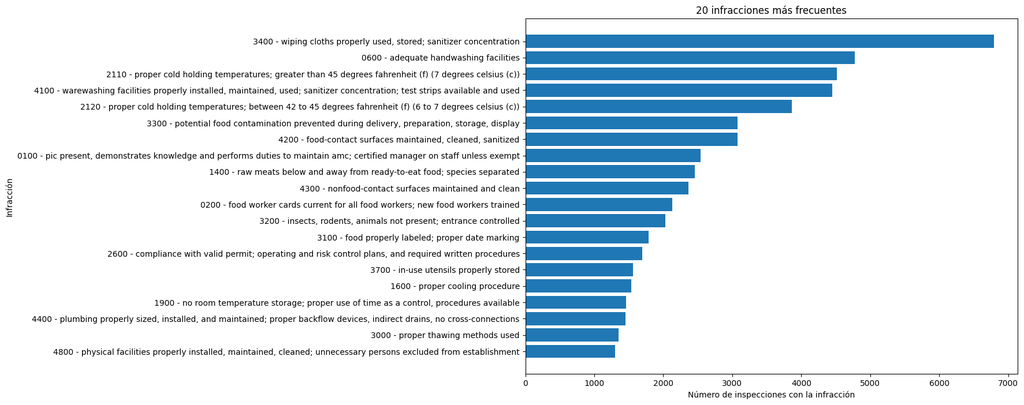

```
export_plot
def export_plot(fig, path)
```

```
/tmp/ipykernel_1037/816432270.py<no docstring>
```

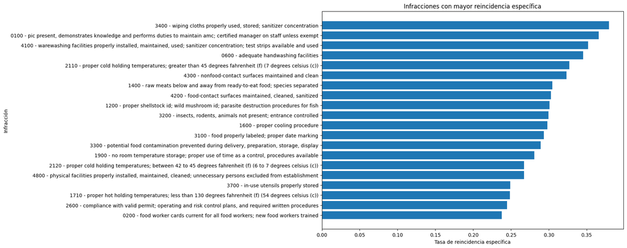

```
export_plot
def export_plot(fig, path)
```

```
/tmp/ipykernel_1037/816432270.py<no docstring>
```

```
Análisis de infracciones terminado.

--- global_violations ---
```

|  | violation_description_clean | rows | inspections | businesses | total_points | mean_points | businesses_for_recurrence_rate | businesses_recurrent | mean_inspections_per_business | specific_recurrence_rate |
| --- | --- | --- | --- | --- | --- | --- | --- | --- | --- | --- |
| 35 | 3400 - wiping cloths properly used, stored; sa... | 6797 | 6797 | 4261 | 33985 | 5.0 | 4261 | 1618 | 1.595165 | 0.379723 |
| 5 | 0600 - adequate handwashing facilities | 4775 | 4775 | 3091 | 47750 | 10.0 | 3091 | 1067 | 1.544808 | 0.345196 |
| 21 | 2110 - proper cold holding temperatures; great... | 4518 | 4518 | 3028 | 45180 | 10.0 | 3028 | 990 | 1.492074 | 0.326948 |
| 42 | 4100 - warewashing facilities properly install... | 4453 | 4453 | 2887 | 22265 | 5.0 | 2887 | 1016 | 1.542432 | 0.351922 |
| 22 | 2120 - proper cold holding temperatures; betwe... | 3865 | 3865 | 2823 | 19325 | 5.0 | 2823 | 755 | 1.369111 | 0.267446 |
| 34 | 3300 - potential food contamination prevented ... | 3076 | 3076 | 2153 | 15380 | 5.0 | 2153 | 623 | 1.428704 | 0.289364 |
| 43 | 4200 - food-contact surfaces maintained, clean... | 3073 | 3073 | 2128 | 15365 | 5.0 | 2128 | 644 | 1.444079 | 0.302632 |
| 0 | 0100 - pic present, demonstrates knowledge and... | 2540 | 2540 | 1591 | 12700 | 5.0 | 1591 | 582 | 1.596480 | 0.365808 |
| 13 | 1400 - raw meats below and away from ready-to-... | 2461 | 2461 | 1696 | 12305 | 5.0 | 1696 | 517 | 1.451061 | 0.304835 |
| 44 | 4300 - nonfood-contact surfaces maintained and... | 2366 | 2366 | 1513 | 7098 | 3.0 | 1513 | 489 | 1.563781 | 0.323199 |
| 1 | 0200 - food worker cards current for all food ... | 2133 | 2133 | 1581 | 10665 | 5.0 | 1581 | 376 | 1.349146 | 0.237824 |
| 33 | 3200 - insects, rodents, animals not present; ... | 2027 | 2027 | 1331 | 10135 | 5.0 | 1331 | 399 | 1.522915 | 0.299775 |
| 32 | 3100 - food properly labeled; proper date marking | 1786 | 1786 | 1230 | 8930 | 5.0 | 1230 | 361 | 1.452033 | 0.293496 |
| 27 | 2600 - compliance with valid permit; operating... | 1694 | 1694 | 1255 | 16940 | 10.0 | 1255 | 307 | 1.349801 | 0.244622 |
| 38 | 3700 - in-use utensils properly stored | 1560 | 1560 | 1169 | 4680 | 3.0 | 1169 | 291 | 1.334474 | 0.248931 |
| 15 | 1600 - proper cooling procedure | 1534 | 1534 | 1060 | 38350 | 25.0 | 1060 | 316 | 1.447170 | 0.298113 |
| 19 | 1900 - no room temperature storage; proper use... | 1457 | 1457 | 1007 | 36425 | 25.0 | 1007 | 283 | 1.446872 | 0.281033 |
| 45 | 4400 - plumbing properly sized, installed, and... | 1451 | 1451 | 1111 | 7255 | 5.0 | 1111 | 244 | 1.306031 | 0.219622 |
| 31 | 3000 - proper thawing methods used | 1349 | 1349 | 1027 | 4047 | 3.0 | 1027 | 238 | 1.313535 | 0.231743 |
| 49 | 4800 - physical facilities properly installed,... | 1301 | 1301 | 909 | 2602 | 2.0 | 909 | 243 | 1.431243 | 0.267327 |

```
--- top_by_class ---
```

|  | classification | violation_description_clean | inspections | businesses | total_points | mean_points | share_within_classification |
| --- | --- | --- | --- | --- | --- | --- | --- |
| 22 | bakery | 3400 - wiping cloths properly used, stored; sa... | 101 | 67 | 505 | 5.0 | 0.168053 |
| 29 | bakery | 4100 - warewashing facilities properly install... | 87 | 55 | 435 | 5.0 | 0.144759 |
| 4 | bakery | 0600 - adequate handwashing facilities | 56 | 43 | 560 | 10.0 | 0.093178 |
| 21 | bakery | 3300 - potential food contamination prevented ... | 34 | 27 | 170 | 5.0 | 0.056572 |
| 31 | bakery | 4300 - nonfood-contact surfaces maintained and... | 34 | 24 | 102 | 3.0 | 0.056572 |
| 1 | bakery | 0200 - food worker cards current for all food ... | 27 | 21 | 135 | 5.0 | 0.044925 |
| 30 | bakery | 4200 - food-contact surfaces maintained, clean... | 24 | 21 | 120 | 5.0 | 0.039933 |
| 36 | bakery | 4800 - physical facilities properly installed,... | 20 | 17 | 40 | 2.0 | 0.033278 |
| 12 | bakery | 2110 - proper cold holding temperatures; great... | 19 | 19 | 190 | 10.0 | 0.031614 |
| 13 | bakery | 2120 - proper cold holding temperatures; betwe... | 17 | 14 | 85 | 5.0 | 0.028286 |
| 39 | bed and breakfast operation | 0200 - food worker cards current for all food ... | 1 | 1 | 5 | 5.0 | 0.250000 |
| 40 | bed and breakfast operation | 2120 - proper cold holding temperatures; betwe... | 1 | 1 | 5 | 5.0 | 0.250000 |
| 41 | bed and breakfast operation | 2200 - accurate thermometer provided and used ... | 1 | 1 | 5 | 5.0 | 0.250000 |
| 42 | bed and breakfast operation | 3400 - wiping cloths properly used, stored; sa... | 1 | 1 | 5 | 5.0 | 0.250000 |
| 73 | catering operation | 3400 - wiping cloths properly used, stored; sa... | 69 | 55 | 345 | 5.0 | 0.122995 |
| 79 | catering operation | 4100 - warewashing facilities properly install... | 54 | 38 | 270 | 5.0 | 0.096257 |
| 43 | catering operation | 0100 - pic present, demonstrates knowledge and... | 45 | 32 | 225 | 5.0 | 0.080214 |
| 47 | catering operation | 0600 - adequate handwashing facilities | 31 | 25 | 310 | 10.0 | 0.055258 |
| 66 | catering operation | 2600 - compliance with valid permit; operating... | 30 | 24 | 300 | 10.0 | 0.053476 |
| 53 | catering operation | 1400 - raw meats below and away from ready-to-... | 25 | 24 | 125 | 5.0 | 0.044563 |

```
--- by_business ---
```

|  | violation_description_clean | business_id | name | classification | city | inspections_with_violation | total_points |
| --- | --- | --- | --- | --- | --- | --- | --- |
| 78 | 0100 - pic present, demonstrates knowledge and... | pfe-pr-3127686 | red onion tavern | general food services | seattle | 8 | 40 |
| 316 | 0100 - pic present, demonstrates knowledge and... | pfe-pr-3130274 | subway factoria | general food services | bellevue | 8 | 40 |
| 1217 | 0100 - pic present, demonstrates knowledge and... | pfe-pr-3145493 | tian fu | general food services | seattle | 8 | 40 |
| 317 | 0100 - pic present, demonstrates knowledge and... | pfe-pr-3130288 | tokyo japanese restaurant | general food services | bellevue | 7 | 35 |
| 681 | 0100 - pic present, demonstrates knowledge and... | pfe-pr-3135252 | mirch masala town | general food services | kent | 7 | 35 |
| 992 | 0100 - pic present, demonstrates knowledge and... | pfe-pr-3141454 | pho hien trang llc | general food services | renton | 7 | 35 |
| 50 | 0100 - pic present, demonstrates knowledge and... | pfe-pr-3127355 | patio fine thai cuisine | general food services | seattle | 6 | 30 |
| 109 | 0100 - pic present, demonstrates knowledge and... | pfe-pr-3128046 | 7-eleven, inc/mkt 2361- 27284b | general food services | federal way | 6 | 30 |
| 145 | 0100 - pic present, demonstrates knowledge and... | pfe-pr-3128462 | asian pacific market and deli | general food services | kent | 6 | 30 |
| 291 | 0100 - pic present, demonstrates knowledge and... | pfe-pr-3130034 | 7-eleven #38807a | general food services | kent | 6 | 30 |
| 408 | 0100 - pic present, demonstrates knowledge and... | pfe-pr-3131296 | tasty thai | general food services | bellevue | 6 | 30 |
| 413 | 0100 - pic present, demonstrates knowledge and... | pfe-pr-3131327 | pickled onion | general food services | renton | 6 | 30 |
| 483 | 0100 - pic present, demonstrates knowledge and... | pfe-pr-3132103 | rolls & rolls plus sushi | general food services | bellevue | 6 | 30 |
| 705 | 0100 - pic present, demonstrates knowledge and... | pfe-pr-3135592 | subway #24019 | general food services | federal way | 6 | 30 |
| 840 | 0100 - pic present, demonstrates knowledge and... | pfe-pr-3137982 | subway 38699 | general food services | kent | 6 | 30 |
| 949 | 0100 - pic present, demonstrates knowledge and... | pfe-pr-3140487 | subway store #40142 | general food services | federal way | 6 | 30 |
| 1311 | 0100 - pic present, demonstrates knowledge and... | pfe-pr-3146856 | burger & kabob hut | general food services | bellevue | 6 | 30 |
| 42 | 0100 - pic present, demonstrates knowledge and... | pfe-pr-3127243 | 7-eleven #14470b | general food services | seattle | 5 | 25 |
| 57 | 0100 - pic present, demonstrates knowledge and... | pfe-pr-3127448 | fang llc dba mike's noodle house | general food services | seattle | 5 | 25 |
| 175 | 0100 - pic present, demonstrates knowledge and... | pfe-pr-3128874 | ruchi indian restaurant | general food services | bellevue | 5 | 25 |

```python
violation_tables = analyze_violations(raw, inspections)

print('Análisis de infracciones terminado.')

for key, table in violation_tables.items():
    print(f'\n--- {key} ---')
    display(table.head(20))
```

## Generación de archivos

Todos estos archivos se almacenan en una carpeta específica para facilitar su gestión.

```python
create_dashboard_files(
    inspections, recurrence, first_model,
    risk_tables, violation_tables, interval_df
)

print('\n TODOS LOS ARCHIVOS HAN SIDO GENERADOS EN:')
print(OUTPUT_DIR)
```

```
================================================================================
 ARCHIVOS PARA DASHBOARD
================================================================================
CSV creados en: /content/TFM_INSPECCIONES/resultados

 TODOS LOS ARCHIVOS HAN SIDO GENERADOS EN:
/content/TFM_INSPECCIONES/resultados
```

## Fecha recomendada para la inspeción.

El complemento de los cálculos realizados, y como apoyo a los inspectores, se incorpora una función que les ayuda a predecir la mejor fecha para la inspección, que conjuga la información recopilada para establecer una fecha potencialmente ideal para cada establecimiento así como cuál sería el mejor intervalo para llevarla a cabo. Al igual que con el supuesto anterior, en ningún caso debe entenderse que el llevar a cabo la inspección en esas fechas garantice la no reincidencia, pero su explotación podría ser de utilidad para mejorar los resultados. En este caso, se eligen exclusivamente los establecimientos que ya han tenido una evaluación.

También, a modo de toque de atención, se establece un ranking entre la prioridad de cara a fijar los calendarios, con fijando umbrales de posibilidades de reincidencia (0.4, 0.6, 0.8) para orientar al inspector de cara a agendar sus trabajos, fijándose una ventana en el calendario para llevarlos a cabo.

```python
def predict_recommended_inspection_dates(recurrence):


    model_base = recurrence["model_base"].copy()
    model = recurrence["best_model"]
    cats = recurrence["categorical"]
    nums = recurrence["numeric"]

    # Establecimientos elegibles sólo los que ya han sido inspeccionados


    eligible = model_base[
        model_base["previous_inspections"] >= 1
    ].copy()

    if eligible.empty:
        return pd.DataFrame()


    #  Intervalos candidatos

    candidate_intervals = INTERVAL_CANDIDATES

    results = []


    # Evaluación establecimiento por establecimiento


    for business_id, group in eligible.groupby("business_id"):

        # Última observación conocida
        group = group.sort_values(
            ["inspection_date", "inspection_serial_num"]
        )

        row = group.iloc[-1].copy()

        candidate_results = []

        for days in candidate_intervals:

            scenario = pd.DataFrame(
                [row.to_dict()]
            )

            scenario["planned_days_to_next"] = days

            X = scenario[cats + nums]

            probability = model.predict_proba(X)[0, 1]

            candidate_results.append({
                "planned_interval_days": days,
                "predicted_probability": probability
            })

        candidate_df = pd.DataFrame(candidate_results)

        # Intervalo de menor riesgo


        best_idx = candidate_df[
            "predicted_probability"
        ].idxmin()

        best = candidate_df.loc[best_idx]

        recommended_interval = int(
            best["planned_interval_days"]
        )

        predicted_probability = float(
            best["predicted_probability"]
        )

        # Fecha recomendada


        last_date = pd.to_datetime(
            row["inspection_date"]
        )

        recommended_date = (
            last_date
            + pd.Timedelta(
                days=recommended_interval
            )
        )


        # Fecha actual


        today = pd.Timestamp.today().normalize()

        days_until = (
            recommended_date - today
        ).days

        # Prioridad


        if predicted_probability >= 0.80:
            priority = "Urgency"

        elif predicted_probability >= 0.60:
            priority = "High"

        elif predicted_probability >= 0.40:
            priority = "Medium"

        else:
            priority = "Low"

        # Ventana recomendada


        window_start = (
            recommended_date
            - pd.Timedelta(days=15)
        )

        window_end = (
            recommended_date
            + pd.Timedelta(days=15)
        )

        # Guardar resultado


        results.append({

            "business_id":
                business_id,

            "name":
                row.get("name", np.nan),

            "city":
                row.get("city", np.nan),

            "zip_code":
                row.get("zip_code", np.nan),

            "last_inspection_date":
                last_date,

            "last_inspection_result":
                row.get(
                    "inspection_result",
                    np.nan
                ),

            "current_probability_recurrence":
                row.get(
                    "probability_recurrence",
                    np.nan
                ),

            "current_risk_group":
                row.get(
                    "risk_group",
                    np.nan
                ),

            "recommended_interval_days":
                recommended_interval,

            "recommended_interval_months":
                round(
                    recommended_interval / 30.4375,
                    1
                ),

            "recommended_inspection_probability":
                predicted_probability,

            "recommended_inspection_date":
                recommended_date,

            "days_until_recommended_inspection":
                days_until,

            "recommended_window_start":
                window_start,

            "recommended_window_end":
                window_end,

            "inspection_priority":
                priority
        })

    recommended_df = pd.DataFrame(results)


    # Exportar


    output_path = (
        OUTPUT_DIR /
        "recommended_inspection_dates.csv"
    )

    recommended_df.to_csv(
        output_path,
        index=False,
        encoding="utf-8-sig"
    )

    print(
        "\n Fechas recomendadas calculadas"
    )

    print(
        f"Establecimientos: "
        f"{len(recommended_df):,}"
    )

    print(
        f"Archivo: {output_path}"
    )

    return recommended_df
```

```python
recommended_dates = (
    predict_recommended_inspection_dates(
        recurrence
    )
)

display(
    recommended_dates.head(20)
)
```

```
 Fechas recomendadas calculadas
Establecimientos: 10,442
Archivo: /content/TFM_INSPECCIONES/resultados/recommended_inspection_dates.csv
```

|  | business_id | name | city | zip_code | last_inspection_date | last_inspection_result | current_probability_recurrence | current_risk_group | recommended_interval_days | recommended_interval_months | recommended_inspection_probability | recommended_inspection_date | days_until_recommended_inspection | recommended_window_start | recommended_window_end | inspection_priority |
| --- | --- | --- | --- | --- | --- | --- | --- | --- | --- | --- | --- | --- | --- | --- | --- | --- |
| 0 | pfe-pr-3126712 | old fifth ave llc | seattle | 98115 | 2025-08-05 | satisfactory | NaN | NaN | 90 | 3.0 | 0.233446 | 2025-11-03 | -318 | 2025-10-19 | 2025-11-18 | Low |
| 1 | pfe-pr-3126713 | zouave restaurant | seattle | 98115 | 2025-07-01 | unsatisfactory | NaN | NaN | 30 | 1.0 | 0.542425 | 2025-07-31 | -413 | 2025-07-16 | 2025-08-15 | Medium |
| 2 | pfe-pr-3126715 | 7-eleven store #2360-14373c | seattle | 98115 | 2025-01-22 | satisfactory | NaN | NaN | 30 | 1.0 | 0.578531 | 2025-02-21 | -573 | 2025-02-06 | 2025-03-08 | Medium |
| 3 | pfe-pr-3126716 | 7-eleven store #2360-14360a | seattle | 98107 | 2025-02-25 | unsatisfactory | NaN | NaN | 30 | 1.0 | 0.591146 | 2025-03-27 | -539 | 2025-03-12 | 2025-04-11 | Medium |
| 4 | pfe-pr-3126718 | 7-eleven #16022g | seattle | 98103 | 2025-03-19 | satisfactory | NaN | NaN | 30 | 1.0 | 0.224272 | 2025-04-18 | -517 | 2025-04-03 | 2025-05-03 | Low |
| 5 | pfe-pr-3126720 | the local 104 | lake forest park | 98155 | 2025-06-11 | satisfactory | NaN | NaN | 30 | 1.0 | 0.317220 | 2025-07-11 | -433 | 2025-06-26 | 2025-07-26 | Low |
| 6 | pfe-pr-3126723 | 7-eleven store #22625d | shoreline | 98155 | 2025-09-23 | unsatisfactory | NaN | NaN | 30 | 1.0 | 0.550139 | 2025-10-23 | -329 | 2025-10-08 | 2025-11-07 | Medium |
| 7 | pfe-pr-3126725 | 7-eleven store #14354d | shoreline | 98155 | 2025-03-26 | unsatisfactory | NaN | NaN | 30 | 1.0 | 0.706145 | 2025-04-25 | -510 | 2025-04-10 | 2025-05-10 | High |
| 8 | pfe-pr-3126726 | sodhi holdings inc dba 7-eleven store #14396e | seattle | 98115 | 2024-04-24 | unsatisfactory | NaN | NaN | 30 | 1.0 | 0.800962 | 2024-05-24 | -846 | 2024-05-09 | 2024-06-08 | Urgency |
| 9 | pfe-pr-3126727 | 7-eleven #18553e | seattle | 98103 | 2025-10-30 | satisfactory | NaN | NaN | 90 | 3.0 | 0.158530 | 2026-01-28 | -232 | 2026-01-13 | 2026-02-12 | Low |
| 10 | pfe-pr-3126730 | adams elementary school | seattle | 98107 | 2025-09-16 | satisfactory | NaN | NaN | 30 | 1.0 | 0.168214 | 2025-10-16 | -336 | 2025-10-01 | 2025-10-31 | Low |
| 11 | pfe-pr-3126731 | al's tavern | seattle | 98103 | 2025-05-14 | satisfactory | NaN | NaN | 690 | 22.7 | 0.050410 | 2027-04-04 | 199 | 2027-03-20 | 2027-04-19 | Low |
| 12 | pfe-pr-3126735 | albertsons #3416 | lake forest park | 98155 | 2024-04-22 | satisfactory | NaN | NaN | 690 | 22.7 | 0.030042 | 2026-03-13 | -188 | 2026-02-26 | 2026-03-28 | Low |
| 13 | pfe-pr-3126736 | albertsons #3416 | lake forest park | 98155 | 2024-10-15 | satisfactory | NaN | NaN | 690 | 22.7 | 0.339383 | 2026-09-05 | -12 | 2026-08-21 | 2026-09-20 | Low |
| 14 | pfe-pr-3126742 | allegro espresso bar | seattle | 98105 | 2024-01-18 | satisfactory | NaN | NaN | 690 | 22.7 | 0.041452 | 2025-12-08 | -283 | 2025-11-23 | 2025-12-23 | Low |
| 15 | pfe-pr-3126743 | alpha chi omega | seattle | 98105 | 2025-06-03 | unsatisfactory | NaN | NaN | 30 | 1.0 | 0.577430 | 2025-07-03 | -441 | 2025-06-18 | 2025-07-18 | Medium |
| 16 | pfe-pr-3126745 | alpha delta pi | seattle | 98105 | 2025-10-07 | satisfactory | NaN | NaN | 690 | 22.7 | 0.363203 | 2027-08-28 | 345 | 2027-08-13 | 2027-09-12 | Low |
| 17 | pfe-pr-3126746 | alpha gamma delta | seattle | 98105 | 2025-03-05 | satisfactory | NaN | NaN | 60 | 2.0 | 0.328755 | 2025-05-04 | -501 | 2025-04-19 | 2025-05-19 | Low |
| 18 | pfe-pr-3126747 | alpha phi | seattle | 98105 | 2025-12-05 | satisfactory | NaN | NaN | 30 | 1.0 | 0.377943 | 2026-01-04 | -256 | 2025-12-20 | 2026-01-19 | Low |
| 19 | pfe-pr-3126749 | alpha xi delta | seattle | 98105 | 2024-05-01 | satisfactory | NaN | NaN | 30 | 1.0 | 0.318396 | 2024-05-31 | -839 | 2024-05-16 | 2024-06-15 | Low |

```python
null_counts = recommended_dates.isna().sum()
print(null_counts)
```

```
business_id                               0
name                                      0
city                                      0
zip_code                                  0
last_inspection_date                      0
last_inspection_result                    0
current_probability_recurrence        10442
current_risk_group                    10442
recommended_interval_days                 0
recommended_interval_months               0
recommended_inspection_probability        0
recommended_inspection_date               0
days_until_recommended_inspection         0
recommended_window_start                  0
recommended_window_end                    0
inspection_priority                       0
dtype: int64
```

## Crear los CSV unificado para el dashboard

La siguiente celda genera los archivos finales. Están pensados, como anunciábamos, para su utilización en herramientas como Power BI, Tableau, Looker Studio o un dashboard propio. Para este caso concreto, y dado que al ir elaborando el dashboard se habrían detectado algunas dificultades de cara a cómo tableau interpreta los archivos, se han optimizado para esa herramienta, pero nada impide su utilización en cualquier otra. En todo caso, en su elaboración se han tenido en cuenta la información que se ha considerado más relevante, si bien, como ya se ha dicho, el código esta preparado para generar tantos csv como apartados específicos de información se han tratado, que en cualquier momento pueden ser incorporados como fuentes para aumentar las opciones de la herramienta a demanda de los usuarios finales, sirviendo como complemento a la información que se ha decidido incorporar en el archivo maestro únicamente pensado para facilitar la gestión de la carga a los usuarios finales. En el propio git se incluye una posible propuesta de diseño que ejemplifica el potencial útil del trabajo.

```python
# DATASET MAESTRO FINAL PARA TABLEAU


import numpy as np
import pandas as pd
from pathlib import Path
import re
import csv


def clean_tableau_column_name(col):

    col = str(col).strip()

    # Sustituir espacios por _
    col = re.sub(r"\s+", "_", col)

    # Mantener únicamente caracteres alfanuméricos y _
    col = re.sub(r"[^A-Za-z0-9_]", "_", col)

    # Evitar varios "_" consecutivos
    col = re.sub(r"_+", "_", col)

    # Eliminar "_" al principio y final
    col = col.strip("_")

    # Evitar nombres vacíos
    if col == "":
        col = "campo"

    return col


def make_unique_columns(columns):
    """
    Evita nombres de columnas duplicados.
    """

    seen = {}
    result = []

    for col in columns:

        if col not in seen:

            seen[col] = 0
            result.append(col)

        else:

            seen[col] += 1
            result.append(
                f"{col}_{seen[col]}"
            )

    return result


def create_tableau_master(
    inspections,
    recurrence,
    first_model,
    recommended_dates,
    output_dir=OUTPUT_DIR
):

    print("=" * 80)
    print("CREACIÓN DEL DATASET MAESTRO FINAL PARA TABLEAU")
    print("=" * 80)

    # COPIA DE INSPECCIONES

    df = inspections.copy()


    # FECHAS


    df["inspection_date"] = pd.to_datetime(
        df["inspection_date"],
        errors="coerce"
    )

    if "next_inspection_date" in df.columns:

        df["next_inspection_date"] = pd.to_datetime(
            df["next_inspection_date"],
            errors="coerce"
        )


    # ORDEN TEMPORAL


    df = df.sort_values(
        [
            "business_id",
            "inspection_date",
            "inspection_serial_num"
        ]
    ).reset_index(drop=True)

    # VARIABLES TEMPORALES


    df["inspection_year"] = (
        df["inspection_date"].dt.year
        .astype("Int64")
    )

    df["inspection_month"] = (
        df["inspection_date"].dt.month
        .astype("Int64")
    )

    df["inspection_month_name"] = (
        df["inspection_date"]
        .dt.month_name()
    )

    df["inspection_quarter"] = (
        "Q"
        + df["inspection_date"]
        .dt.quarter
        .astype("Int64")
        .astype(str)
    )

    df["inspection_year_month"] = (
        df["inspection_date"]
        .dt.to_period("M")
        .astype(str)
    )

    # RESULTADO DE LA INSPECCIÓN


    result = (
        df["inspection_result"]
        .astype(str)
        .str.strip()
        .str.lower()
    )

    df["is_unsatisfactory"] = (
        result.eq("unsatisfactory")
        .astype(int)
    )

    df["is_satisfactory"] = (
        result.eq("satisfactory")
        .astype(int)
    )

    df["is_complete"] = (
        result.eq("complete")
        .astype(int)
    )


    # VARIABLES DE INFRACCIONES


    if "number_violations" in df.columns:

        df["has_violation"] = (
            pd.to_numeric(
                df["number_violations"],
                errors="coerce"
            )
            .fillna(0)
            > 0
        ).astype(int)

    else:

        df["has_violation"] = (
            pd.to_numeric(
                df["violation_points"],
                errors="coerce"
            )
            .fillna(0)
            > 0
        ).astype(int)

    df["has_violation_points"] = (
        pd.to_numeric(
            df["violation_points"],
            errors="coerce"
        )
        .fillna(0)
        > 0
    ).astype(int)

    for col in [
        "has_red_violation",
        "has_blue_violation"
    ]:

        if col in df.columns:

            df[col] = (
                df[col]
                .fillna(False)
                .astype(int)
            )

    # PRIMERA INSPECCIÓN


    first_date = (
        df.groupby("business_id")[
            "inspection_date"
        ]
        .transform("min")
    )

    df["is_first_observed_inspection"] = (
        df["inspection_date"]
        .eq(first_date)
        .astype(int)
    )


    # ÚLTIMA INSPECCIÓN


    latest_idx = (
        df
        .sort_values(
            [
                "business_id",
                "inspection_date",
                "inspection_serial_num"
            ]
        )
        .groupby("business_id")
        .tail(1)
        .index
    )

    df["is_latest_inspection"] = 0

    df.loc[
        latest_idx,
        "is_latest_inspection"
    ] = 1


    # PREDICCIÓN DE REINCIDENCIA


    recurrence_scored = (
        recurrence["model_base"]
        .copy()
    )

    recurrence_model = (
        recurrence["best_model"]
    )

    recurrence_cats = (
        recurrence["categorical"]
    )

    recurrence_nums = (
        recurrence["numeric"]
    )

    recurrence_features = (
        recurrence_cats
        + recurrence_nums
    )

    recurrence_scored[
        "probability_recurrence"
    ] = (
        recurrence_model
        .predict_proba(
            recurrence_scored[
                recurrence_features
            ]
        )[:, 1]
    )

    recurrence_scored[
        "risk_group"
    ] = add_risk_group(
        recurrence_scored[
            "probability_recurrence"
        ]
    )

    recurrence_predictions = (
        recurrence_scored[
            [
                "inspection_serial_num",
                "probability_recurrence",
                "risk_group"
            ]
        ]
        .drop_duplicates(
            "inspection_serial_num"
        )
    )

    df = df.merge(
        recurrence_predictions,
        on="inspection_serial_num",
        how="left"
    )


    # PREDICCIÓN DE PRIMERA INSPECCIÓN


    first = (
        first_model["first"]
        .copy()
    )

    first_model_fitted = (
        first_model["model"]
    )

    first_cats = (
        first_model["categorical"]
    )

    first_nums = (
        first_model["numeric"]
    )

    first_features = (
        first_cats
        + first_nums
    )

    first_scored = first[
        [
            "business_id",
            "inspection_date"
        ]
        + first_features
    ].copy()
```

```python
    first_scored[
        "probability_first_inspection_unsatisfactory"
    ] = (
        first_model_fitted
        .predict_proba(
            first_scored[
                first_features
            ]
        )[:, 1]
    )

    first_scored[
        "first_inspection_risk_group"
    ] = add_risk_group(
        first_scored[
            "probability_first_inspection_unsatisfactory"
        ]
    )

    first_predictions = (
        first_scored[
            [
                "business_id",
                "inspection_date",
                "probability_first_inspection_unsatisfactory",
                "first_inspection_risk_group"
            ]
        ]
        .drop_duplicates(
            [
                "business_id",
                "inspection_date"
            ]
        )
    )

    df = df.merge(
        first_predictions,
        on=[
            "business_id",
            "inspection_date"
        ],
        how="left"
    )


    # RIESGO ACTUAL DEL ESTABLECIMIENTO


    latest_risk = (
        df[
            df["is_latest_inspection"] == 1
        ][
            [
                "business_id",
                "probability_recurrence",
                "risk_group"
            ]
        ]
        .drop_duplicates(
            "business_id"
        )
        .rename(
            columns={
                "probability_recurrence":
                    "current_probability_recurrence",

                "risk_group":
                    "current_risk_group"
            }
        )
    )

    df = df.merge(
        latest_risk,
        on="business_id",
        how="left"
    )

      # PORCENTAJES


    if "previous_unsatisfactory_rate" in df.columns:

        df["previous_unsatisfactory_rate_pct"] = (
            df["previous_unsatisfactory_rate"]
            * 100
        )

    if "probability_recurrence" in df.columns:

        df["probability_recurrence_pct"] = (
            df["probability_recurrence"]
            * 100
        )

    if (
        "probability_first_inspection_unsatisfactory"
        in df.columns
    ):

        df[
            "probability_first_inspection_unsatisfactory_pct"
        ] = (
            df[
                "probability_first_inspection_unsatisfactory"
            ]
            * 100
        )

    if "current_probability_recurrence" in df.columns:

        df["current_probability_recurrence_pct"] = (
            df["current_probability_recurrence"]
            * 100
        )

    # DISTANCIA TEMPORAL A SIGUIENTE INSPECCIÓN

    if "days_to_next_inspection" in df.columns:

        df["next_inspection_days"] = pd.to_numeric(
            df["days_to_next_inspection"],
            errors="coerce"
        )


    # CAMPOS GEOGRÁFICOS
    # Para explotar la funcionalidad de tableau que permite ubicar puntos en el mapa

    for col in [
        "address",
        "city",
        "zip_code"
    ]:

        if col in df.columns:

            df[col] = (
                df[col]
                .astype(str)
                .replace(
                    [
                        "nan",
                        "None",
                        "<NA>"
                    ],
                    ""
                )
                .str.strip()
            )

    df["location_label"] = (
        df["address"].fillna("")
        + ", "
        + df["city"].fillna("")
        + " "
        + df["zip_code"].fillna("")
    ).str.strip()

    # INCORPORAR RECOMENDACIÓN DE FECHA


    if (
        recommended_dates is not None
        and not recommended_dates.empty
    ):

        recommendation_columns = [
            "business_id",
            "last_inspection_date",
            "recommended_interval_days",
            "recommended_interval_months",
            "recommended_inspection_probability",
            "recommended_inspection_date",
            "days_until_recommended_inspection",
            "recommended_window_start",
            "recommended_window_end",
            "inspection_priority"
        ]

        recommendation_columns = [
            c
            for c in recommendation_columns
            if c in recommended_dates.columns
        ]

        recommendations = (
            recommended_dates[
                recommendation_columns
            ]
            .drop_duplicates(
                "business_id"
            )
        )

        df = df.merge(
            recommendations,
            on="business_id",
            how="left"
        )

        print(
            "\n Variables de planificación "
            "incorporadas."
        )


    # FECHAS DE PLANIFICACIÓN


    planning_dates = [
        "last_inspection_date",
        "recommended_inspection_date",
        "recommended_window_start",
        "recommended_window_end"
    ]

    for col in planning_dates:

        if col in df.columns:

            df[col] = pd.to_datetime(
                df[col],
                errors="coerce"
            )

    # ESTADO DE PLANIFICACIÓN


    if "days_until_recommended_inspection" in df.columns:

        days = pd.to_numeric(
            df[
                "days_until_recommended_inspection"
            ],
            errors="coerce"
        )

        df["inspection_planning_status"] = np.select(

            [
                days < 0,
                days <= 30,
                days <= 90,
                days > 90
            ],

            [
                "Atrasada",
                "Próxima - 30 días",
                "Próxima - 90 días",
                "Programable"
            ],

            default="Sin recomendación"
        )


    # IDS COMO TEXTO


    id_columns = [
        "business_id",
        "inspection_serial_num",
        "zip_code",
        "parcel_number"
    ]

    for col in id_columns:

        if col in df.columns:

            df[col] = (
                df[col]
                .fillna("")
                .astype(str)
                .str.strip()
            )


    # VARIABLES BINARIAS COMO 0 / 1


    binary_columns = [
        "is_unsatisfactory",
        "is_satisfactory",
        "is_complete",
        "has_violation",
        "has_violation_points",
        "has_red_violation",
        "has_blue_violation",
        "is_first_observed_inspection",
        "is_latest_inspection"
    ]
```

```python
    for col in binary_columns:

        if col in df.columns:

            df[col] = (
                pd.to_numeric(
                    df[col],
                    errors="coerce"
                )
                .fillna(0)
                .astype(int)
            )

    # NOMBRES MÁS DESCRIPTIVOS PARA EL DASHBOARD

    rename_map = {

        "name":
            "establishment_name",

        "inspection_serial_num":
            "inspection_id",

        "probability_recurrence":
            "recurrence_probability",

        "probability_recurrence_pct":
            "recurrence_probability_pct",

        "risk_group":
            "recurrence_risk_group",

        "current_probability_recurrence":
            "current_recurrence_probability",

        "current_probability_recurrence_pct":
            "current_recurrence_probability_pct",

        "probability_first_inspection_unsatisfactory":
            "first_inspection_probability",

        "probability_first_inspection_unsatisfactory_pct":
            "first_inspection_probability_pct"
    }

    rename_map = {
        old: new
        for old, new in rename_map.items()
        if old in df.columns
    }

    df = df.rename(
        columns=rename_map
    )


    # LIMPIAR CABECERAS
    # Se incorpora tras verificar que tableau no leía correctamente los datos

    df.columns = [
        clean_tableau_column_name(c)
        for c in df.columns
    ]

    df.columns = make_unique_columns(
        df.columns
    )

   #  ORDEN DE COLUMNAS

    preferred_columns = [

        # IDENTIFICACIÓN
        "business_id",
        "establishment_name",
        "inspection_id",

        # LOCALIZACIÓN
        "address",
        "city",
        "zip_code",
        "location_label",

        # CARACTERÍSTICAS
        "classification",
        "seating_range",
        "risk_category",
        "grade",

        # INSPECCIÓN
        "inspection_date",
        "inspection_year",
        "inspection_month",
        "inspection_month_name",
        "inspection_quarter",
        "inspection_year_month",
        "inspection_type",
        "inspection_score",
        "inspection_result",
        "inspection_closed_business",

        # INDICADORES
        "is_unsatisfactory",
        "is_satisfactory",
        "is_complete",
        "is_first_observed_inspection",
        "is_latest_inspection",

        # INFRACCIONES
        "number_violations",
        "violation_points",
        "has_violation",
        "has_violation_points",
        "has_red_violation",
        "has_blue_violation",
        "violation_type",
        "violation_description",
        "violation_set",

        # HISTÓRICO
        "previous_inspections",
        "previous_unsatisfactory",
        "previous_unsatisfactory_rate",
        "previous_unsatisfactory_rate_pct",
        "unsat_last_3",
        "violations_last_3",
        "points_last_3",
        "points_trend_last_5",
        "days_since_previous",
        "previous_inspection_points",

        # SIGUIENTE INSPECCIÓN
        "next_inspection_date",
        "days_to_next_inspection",
        "next_inspection_days",
        "next_inspection_result",

        # REINCIDENCIA
        "recurrence_probability",
        "recurrence_probability_pct",
        "recurrence_risk_group",

        # RIESGO ACTUAL
        "current_recurrence_probability",
        "current_recurrence_probability_pct",
        "current_risk_group",

        # PRIMERA INSPECCIÓN
        "first_inspection_probability",
        "first_inspection_probability_pct",
        "first_inspection_risk_group",

        # PLANIFICACIÓN
        "last_inspection_date",
        "recommended_interval_days",
        "recommended_interval_months",
        "recommended_inspection_probability",
        "recommended_inspection_date",
        "days_until_recommended_inspection",
        "recommended_window_start",
        "recommended_window_end",
        "inspection_priority",
        "inspection_planning_status"
    ]

    ordered = [
        c
        for c in preferred_columns
        if c in df.columns
    ]

    remaining = [
        c
        for c in df.columns
        if c not in ordered
    ]

    df = df[
        ordered + remaining
    ]

    # FORMATO DE FECHAS PARA TABLEAU


    date_columns_final = [
        "inspection_date",
        "next_inspection_date",
        "last_inspection_date",
        "recommended_inspection_date",
        "recommended_window_start",
        "recommended_window_end"
    ]

    for col in date_columns_final:

        if col in df.columns:

            df[col] = pd.to_datetime(
                df[col],
                errors="coerce"
            ).dt.strftime(
                "%Y-%m-%d"
            )

    # ORDEN FINAL DE LOS REGISTROS
    sort_columns = [
        c
        for c in [
            "business_id",
            "inspection_date",
            "inspection_id"
        ]
        if c in df.columns
    ]

    df = (
        df
        .sort_values(sort_columns)
        .reset_index(drop=True)
    )


    # EXPORTACIÓN DEFINITIVA


    output_dir = Path(output_dir)

    output_dir.mkdir(
        parents=True,
        exist_ok=True
    )

    output_path = (
        output_dir
        / "tableau_master_inspections.csv"
    )



    df.to_csv(
        output_path,
        index=False,
        header=True,
        encoding="utf-8-sig",
        sep=",",
        decimal=".",
        quoting=csv.QUOTE_MINIMAL
    )

    # COMPROBACIÓN REAL DEL CSV

    tableau_check = pd.read_csv(
        output_path,
        encoding="utf-8-sig",
        sep=","
    )

    print("\n" + "=" * 80)
    print(" DATASET MAESTRO DEFINITIVO PARA TABLEAU")
    print("=" * 80)

    print(
        f"Archivo: {output_path}"
    )

    print(
        f"Filas: {len(tableau_check):,}"
    )

    print(
        f"Columnas: {len(tableau_check.columns):,}"
    )

    print(
        f"Establecimientos: "
        f"{tableau_check['business_id'].nunique():,}"
    )

    print(
        f"Inspecciones: "
        f"{tableau_check['inspection_id'].nunique():,}"
    )
```

```python
    print("\nCABECERAS QUE RECIBIRÁ TABLEAU:")
    print("-" * 80)

    for i, col in enumerate(
        tableau_check.columns,
        start=1
    ):

        print(
            f"{i:03d}. {col}"
        )

    print("\nPrimeras filas:")
    display(
        tableau_check.head()
    )

    print(
        "\n Comprobación completada."
    )

    print(
        "El CSV contiene una primera fila con "
        "los nombres de los campos."
    )

    return tableau_check


# EJECUCIÓN ÚNICA


tableau_master = create_tableau_master(
    inspections=inspections,
    recurrence=recurrence,
    first_model=first_model,
    recommended_dates=recommended_dates,
    output_dir=OUTPUT_DIR
)


# COPIA DEL DATAFRAME FINAL _ se incorpora aun a riesgo de su aparente duplicidad por haber detectado errores en la subida para los que no se ha encontrado explicación


tableau_final = tableau_master.copy()

# COMPROBAR NOMBRES ORIGINALES DE COLUMNAS

print("=" * 80)
print("COLUMNAS ANTES DE PREPARAR EL ARCHIVO PARA TABLEAU")
print("=" * 80)

for i, col in enumerate(tableau_final.columns, start=1):
    print(f"{i:03d} | {repr(col)}")


# FUNCIÓN PARA LIMPIAR NOMBRES DE COLUMNAS


def limpiar_nombre_columna(nombre):

    # Convertir a texto
    nombre = str(nombre)

    # Eliminar espacios iniciales/finales
    nombre = nombre.strip()

    # Si la columna está vacía
    if nombre == "" or nombre.lower() in ["nan", "none"]:
        nombre = "unnamed_column"

    # Espacios y saltos de línea
    nombre = re.sub(r"\s+", "_", nombre)

    # Caracteres problemáticos
    nombre = re.sub(r"[^A-Za-z0-9_]", "_", nombre)

    # Varios guiones bajos seguidos
    nombre = re.sub(r"_+", "_", nombre)

    # Eliminar guiones bajos extremos
    nombre = nombre.strip("_")

    return nombre

# LIMPIAR LOS NOMBRES

tableau_final.columns = [
    limpiar_nombre_columna(col)
    for col in tableau_final.columns
]

# EVITAR COLUMNAS DUPLICADAS

columnas_finales = []
contador = {}

for col in tableau_final.columns:

    if col not in contador:

        contador[col] = 0
        columnas_finales.append(col)

    else:

        contador[col] += 1

        nuevo_nombre = (
            f"{col}_{contador[col]}"
        )

        columnas_finales.append(
            nuevo_nombre
        )

tableau_final.columns = columnas_finales


# RENOMBRAR VARIABLES PARA QUE SE ENTIENDAN EN TABLEAU


rename_map = {


    # IDENTIFICACIÓN


    "business_id":
        "Business_ID",

    "name":
        "Establishment_Name",

    "establishment_name":
        "Establishment_Name",

    "inspection_serial_num":
        "Inspection_ID",

    "inspection_id":
        "Inspection_ID",


    # ========================================================
    # UBICACIÓN
    # ========================================================

    "address":
        "Address",

    "city":
        "City",

    "zip_code":
        "ZIP_Code",

    "location_label":
        "Location_Label",

    "latitude":
        "Latitude",

    "longitude":
        "Longitude",

    "lat":
        "Latitude",

    "lon":
        "Longitude",



    # CARACTERÍSTICAS DEL ESTABLECIMIENTO


    "classification":
        "Establishment_Classification",

    "seating_range":
        "Seating_Range",

    "risk_category":
        "Risk_Category",

    "grade":
        "Grade",


    # INSPECCIÓN
    "inspection_date":
        "Inspection_Date",

    "inspection_year":
        "Inspection_Year",

    "inspection_month":
        "Inspection_Month",

    "inspection_month_name":
        "Inspection_Month_Name",

    "inspection_quarter":
        "Inspection_Quarter",

    "inspection_year_month":
        "Inspection_Year_Month",

    "inspection_type":
        "Inspection_Type",

    "inspection_score":
        "Inspection_Score",

    "inspection_result":
        "Inspection_Result",

    "inspection_closed_business":
        "Inspection_Closed_Business",

    # RESULTADOS / INDICADORES


    "is_unsatisfactory":
        "Is_Unsatisfactory",

    "is_satisfactory":
        "Is_Satisfactory",

    "is_complete":
        "Is_Complete",

    "is_first_observed_inspection":
        "Is_First_Observed_Inspection",

    "is_latest_inspection":
        "Is_Latest_Inspection",


    # INFRACCIONES


    "number_violations":
        "Number_of_Violations",

    "violation_points":
        "Violation_Points",

    "has_violation":
        "Has_Violation",

    "has_violation_points":
        "Has_Violation_Points",

    "has_red_violation":
        "Has_Red_Violation",

    "has_blue_violation":
        "Has_Blue_Violation",

    "violation_type":
        "Violation_Type",

    "violation_description":
        "Violation_Description",

    "violation_set":
        "Violation_Set",


    # VARIABLES HISTÓRICAS


    "previous_inspections":
        "Previous_Inspections",

    "previous_unsatisfactory":
        "Previous_Unsatisfactory",

    "previous_unsatisfactory_rate":
        "Previous_Unsatisfactory_Rate",

    "previous_unsatisfactory_rate_pct":
        "Previous_Unsatisfactory_Rate_Pct",

    "unsat_last_3":
        "Unsatisfactory_Last_3",

    "violations_last_3":
        "Violations_Last_3",

    "points_last_3":
        "Violation_Points_Last_3",

    "points_trend_last_5":
        "Violation_Points_Trend_Last_5",

    "days_since_previous":
        "Days_Since_Previous_Inspection",

    "previous_inspection_points":
        "Previous_Inspection_Points",


    # SIGUIENTE INSPECCIÓN HISTÓRICA


    "next_inspection_date":
        "Next_Inspection_Date",

    "days_to_next_inspection":
        "Days_To_Next_Inspection",

    "next_inspection_days":
        "Next_Inspection_Days",

    "next_inspection_result":
        "Next_Inspection_Result",


    # MODELO DE REINCIDENCIA


    "probability_recurrence":
        "Recurrence_Probability",

    "recurrence_probability":
        "Recurrence_Probability",

    "probability_recurrence_pct":
        "Recurrence_Probability_Pct",

    "recurrence_probability_pct":
        "Recurrence_Probability_Pct",
```

```python
    "risk_group":
        "Recurrence_Risk_Group",

    "recurrence_risk_group":
        "Recurrence_Risk_Group",

    # RIESGO ACTUAL


    "current_probability_recurrence":
        "Current_Recurrence_Probability",

    "current_recurrence_probability":
        "Current_Recurrence_Probability",

    "current_probability_recurrence_pct":
        "Current_Recurrence_Probability_Pct",

    "current_recurrence_probability_pct":
        "Current_Recurrence_Probability_Pct",

    "current_risk_group":
        "Current_Risk_Group",

    # PRIMERA INSPECCIÓN

    "probability_first_inspection_unsatisfactory":
        "First_Inspection_Unsatisfactory_Probability",

    "first_inspection_probability":
        "First_Inspection_Unsatisfactory_Probability",

    "probability_first_inspection_unsatisfactory_pct":
        "First_Inspection_Unsatisfactory_Probability_Pct",

    "first_inspection_probability_pct":
        "First_Inspection_Unsatisfactory_Probability_Pct",

    "first_inspection_risk_group":
        "First_Inspection_Risk_Group",

    # PLANIFICACIÓN PREDICTIVA

    "last_inspection_date":
        "Last_Inspection_Date",

    "recommended_interval_days":
        "Recommended_Interval_Days",

    "recommended_interval_months":
        "Recommended_Interval_Months",

    "recommended_inspection_probability":
        "Recommended_Inspection_Probability",

    "recommended_inspection_date":
        "Recommended_Inspection_Date",

    "days_until_recommended_inspection":
        "Days_Until_Recommended_Inspection",

    "recommended_window_start":
        "Recommended_Window_Start",

    "recommended_window_end":
        "Recommended_Window_End",

    "inspection_priority":
        "Inspection_Priority",

    "inspection_planning_status":
        "Inspection_Planning_Status"
}


# Aplicar únicamente los nombres existentes
rename_map_final = {
    col: rename_map[col]
    for col in tableau_final.columns
    if col in rename_map
}

tableau_final = tableau_final.rename(
    columns=rename_map_final
)

# ELIMINAR COLUMNAS COMPLETAMENTE VACÍAS


columnas_vacias = [
    col
    for col in tableau_final.columns
    if tableau_final[col].isna().all()
]

if columnas_vacias:

    print("\nColumnas completamente vacías eliminadas:")

    for col in columnas_vacias:
        print(" -", col)

    tableau_final = tableau_final.drop(
        columns=columnas_vacias
    )
# FORMATO DE FECHAS
date_columns = [

    "Inspection_Date",
    "Next_Inspection_Date",
    "Last_Inspection_Date",
    "Recommended_Inspection_Date",
    "Recommended_Window_Start",
    "Recommended_Window_End"
]

for col in date_columns:

    if col in tableau_final.columns:

        tableau_final[col] = pd.to_datetime(
            tableau_final[col],
            errors="coerce"
        ).dt.strftime("%Y-%m-%d")

# ASEGURAR IDs COMO TEXTO


id_columns = [

    "Business_ID",
    "Inspection_ID",
    "ZIP_Code"
]

for col in id_columns:

    if col in tableau_final.columns:

        tableau_final[col] = (
            tableau_final[col]
            .fillna("")
            .astype(str)
            .str.strip()
        )


# COMPROBAR QUE NO HAY NOMBRES F1, F2, ETC.


bad_columns = [
    col
    for col in tableau_final.columns
    if re.fullmatch(
        r"F\d+",
        str(col)
    )
]

if bad_columns:

    print("\n ATENCIÓN")
    print(
        "Existen columnas llamadas F1, F2, etc. "
        "antes de exportar:"
    )

    print(bad_columns)

else:

    print(
        "\n No existen columnas F1, F2, F3... "
        "en el DataFrame final."
    )


# TIPOS DEFINITIVOS PARA TABLEAU

if "Inspection_Year" in tableau_final.columns:
    tableau_final["Inspection_Year"] = (
        pd.to_numeric(
            tableau_final["Inspection_Year"],
            errors="coerce"
        )
        .astype("Int64")
    )

if "Inspection_Month" in tableau_final.columns:
    tableau_final["Inspection_Month"] = (
        pd.to_numeric(
            tableau_final["Inspection_Month"],
            errors="coerce"
        )
        .astype("Int64")
    )

# GUARDAR CSV PARA TABLEAU


output_path = (
    Path(OUTPUT_DIR)
    / "tableau_master_inspections.csv"
)


tableau_final.to_csv(

    output_path,

    index=False,

    header=True,

    sep=";",

    encoding="utf-8-sig",

    decimal=".",

    quoting=csv.QUOTE_MINIMAL,

    quotechar='"',

    lineterminator="\n"
)

# COMPROBACIÓN DEL ARCHIVO REAL GENERADO

tableau_check = pd.read_csv(

    output_path,

    sep=";",

    encoding="utf-8-sig",

    dtype=str,

    keep_default_na=False
)


# VALIDACIONES


print("\n" + "=" * 80)
print("VALIDACIÓN FINAL DEL ARCHIVO PARA TABLEAU")
print("=" * 80)

print(f"\nArchivo: {output_path}")

print(
    f"Filas originales: "
    f"{len(tableau_final):,}"
)

print(
    f"Columnas originales: "
    f"{len(tableau_final.columns):,}"
)

print(
    f"Filas leídas del CSV: "
    f"{len(tableau_check):,}"
)

print(
    f"Columnas leídas del CSV: "
    f"{len(tableau_check.columns):,}"
)


# Validación del número de columnas
if len(tableau_final.columns) == len(tableau_check.columns):

    print(
        "\n CORRECTO: Tableau debería recibir "
        "el mismo número de columnas."
    )

else:

    print(
        "\n ERROR: El número de columnas cambia "
        "al leer el CSV."
    )


# Validación de cabeceras
if list(tableau_final.columns) == list(tableau_check.columns):

    print(
        "CORRECTO: Las cabeceras se han guardado "
        "correctamente."
    )

else:

    print(
        "ERROR: Las cabeceras no coinciden."
    )

# MOSTRAR TODAS LAS COLUMNAS DEFINITIVAS


print("\n" + "=" * 80)
print("CAMPOS QUE DEBERÍAN APARECER EN TABLEAU")
print("=" * 80)

for i, col in enumerate(
    tableau_check.columns,
    start=1
):

    print(
        f"{i:03d} | {col}"
    )



# MUESTRA


print("\nPRIMERAS 5 FILAS:")
display(
    tableau_check.head()
)


# DATAFRAME FINAL


tableau_master = tableau_final
```

```
================================================================================
CREACIÓN DEL DATASET MAESTRO FINAL PARA TABLEAU
================================================================================

 Variables de planificación incorporadas.

================================================================================
 DATASET MAESTRO DEFINITIVO PARA TABLEAU
================================================================================
Archivo: /content/TFM_INSPECCIONES/resultados/tableau_master_inspections.csv
Filas: 72,069
Columnas: 79
Establecimientos: 12,299
Inspecciones: 72,069

CABECERAS QUE RECIBIRÁ TABLEAU:
--------------------------------------------------------------------------------
001. business_id
002. establishment_name
003. inspection_id
004. address
005. city
006. zip_code
007. location_label
008. classification
009. seating_range
010. risk_category
011. grade
012. inspection_date
013. inspection_year
014. inspection_month
015. inspection_month_name
016. inspection_quarter
017. inspection_year_month
018. inspection_type
019. inspection_score
020. inspection_result
021. inspection_closed_business
022. is_unsatisfactory
023. is_satisfactory
```

[output cut: 43 more lines]

```
067. parcel_number
068. violation_descriptions
069. violation_types
070. has_any_violation
071. current_unsatisfactory
072. next_violation_set
073. reincidence
074. specific_recurrence
075. previous_violations
076. previous_violation_points
077. previous_avg_violation_points
078. previous_max_violation_points
079. previous_result

Primeras filas:
```

|  | business_id | establishment_name | inspection_id | address | city | zip_code | location_label | classification | seating_range | risk_category | ... | has_any_violation | current_unsatisfactory | next_violation_set | reincidence | specific_recurrence | previous_violations | previous_violation_points | previous_avg_violation_points | previous_max_violation_points | previous_result |
| --- | --- | --- | --- | --- | --- | --- | --- | --- | --- | --- | --- | --- | --- | --- | --- | --- | --- | --- | --- | --- | --- |
| 0 | pfe-pr-3126712 | old fifth ave llc | pfe-damu1adcx | 8507 5th ave ne | seattle | 98115.0 | 8507 5th ave ne, seattle 98115 | general food services | 13-50 | 3.0 | ... | 0 | 0 | {'3400 - wiping cloths properly used, stored; ... | 0 | 0 | 0.0 | 0.0 | NaN | NaN | NaN |
| 1 | pfe-pr-3126712 | old fifth ave llc | pfe-daxfcpa2p | 8507 5th ave ne | seattle | 98115.0 | 8507 5th ave ne, seattle 98115 | general food services | 13-50 | 3.0 | ... | 1 | 0 | set() | 0 | 0 | 0.0 | 0.0 | 0.000000 | 0.0 | satisfactory |
| 2 | pfe-pr-3126712 | old fifth ave llc | pfe-da1n5mrx7 | 8507 5th ave ne | seattle | 98115.0 | 8507 5th ave ne, seattle 98115 | general food services | 13-50 | 3.0 | ... | 0 | 0 | {'4100 - warewashing facilities properly insta... | 0 | 0 | 1.0 | 5.0 | 2.500000 | 5.0 | satisfactory |
| 3 | pfe-pr-3126712 | old fifth ave llc | pfe-dali0je1y | 8507 5th ave ne | seattle | 98115.0 | 8507 5th ave ne, seattle 98115 | general food services | 13-50 | 3.0 | ... | 1 | 0 | set() | 0 | 0 | 1.0 | 5.0 | 1.666667 | 5.0 | satisfactory |
| 4 | pfe-pr-3126712 | old fifth ave llc | pfe-da8jzf9cc | 8507 5th ave ne | seattle | 98115.0 | 8507 5th ave ne, seattle 98115 | general food services | 13-50 | 3.0 | ... | 0 | 0 | set() | 0 | 0 | 2.0 | 10.0 | 2.500000 | 5.0 | satisfactory |

5 rows × 79 columns

```
 Comprobación completada.
El CSV contiene una primera fila con los nombres de los campos.
================================================================================
COLUMNAS ANTES DE PREPARAR EL ARCHIVO PARA TABLEAU
================================================================================
001 | 'business_id'
002 | 'establishment_name'
003 | 'inspection_id'
004 | 'address'
005 | 'city'
006 | 'zip_code'
007 | 'location_label'
008 | 'classification'
009 | 'seating_range'
010 | 'risk_category'
```

[output cut: 171 more lines]

|  | Business_ID | Establishment_Name | Inspection_ID | Address | City | ZIP_Code | Location_Label | Establishment_Classification | Seating_Range | Risk_Category | ... | has_any_violation | current_unsatisfactory | next_violation_set | reincidence | specific_recurrence | previous_violations | previous_violation_points | previous_avg_violation_points | previous_max_violation_points | previous_result |
| --- | --- | --- | --- | --- | --- | --- | --- | --- | --- | --- | --- | --- | --- | --- | --- | --- | --- | --- | --- | --- | --- |
| 0 | pfe-pr-3126712 | old fifth ave llc | pfe-damu1adcx | 8507 5th ave ne | seattle | 98115.0 | 8507 5th ave ne, seattle 98115 | general food services | 13-50 | 3.0 | ... | 0 | 0 | {'3400 - wiping cloths properly used, stored; ... | 0 | 0 | 0.0 | 0.0 |  |  |  |
| 1 | pfe-pr-3126712 | old fifth ave llc | pfe-daxfcpa2p | 8507 5th ave ne | seattle | 98115.0 | 8507 5th ave ne, seattle 98115 | general food services | 13-50 | 3.0 | ... | 1 | 0 | set() | 0 | 0 | 0.0 | 0.0 | 0.0 | 0.0 | satisfactory |
| 2 | pfe-pr-3126712 | old fifth ave llc | pfe-da1n5mrx7 | 8507 5th ave ne | seattle | 98115.0 | 8507 5th ave ne, seattle 98115 | general food services | 13-50 | 3.0 | ... | 0 | 0 | {'4100 - warewashing facilities properly insta... | 0 | 0 | 1.0 | 5.0 | 2.5 | 5.0 | satisfactory |
| 3 | pfe-pr-3126712 | old fifth ave llc | pfe-dali0je1y | 8507 5th ave ne | seattle | 98115.0 | 8507 5th ave ne, seattle 98115 | general food services | 13-50 | 3.0 | ... | 1 | 0 | set() | 0 | 0 | 1.0 | 5.0 | 1.6666666666666667 | 5.0 | satisfactory |
| 4 | pfe-pr-3126712 | old fifth ave llc | pfe-da8jzf9cc | 8507 5th ave ne | seattle | 98115.0 | 8507 5th ave ne, seattle 98115 | general food services | 13-50 | 3.0 | ... | 0 | 0 | set() | 0 | 0 | 2.0 | 10.0 | 2.5 | 5.0 | satisfactory |

5 rows × 76 columns